# Betting Odds Analysis and Soccer Match Prediction

Sadık Efe Büyükarslan

## Introduction

This study aims to analyze the football match data using statistical and machine learning methods. The objective is to identify patterns and relationships that influence match outcomes, as well as evaluating the performance of bookmakers in setting odds. Under this objective, the bookmaker odds and various match statistics are examined. In the last part, a decision tree model is fitted using both match statistics and newly generated features to capture important relationships between the match outcomes and the features. Moreover, the market efficiency based on the bookmaker's odds is evaluated with this model's result.

```python
#Import libraries
import numpy as np
import pandas as pd
import matplotlib.pyplot as plt
import seaborn as sns
import warnings
from sklearn.model_selection import train_test_split
from sklearn.tree import DecisionTreeClassifier
from sklearn.metrics import accuracy_score, classification_report, confusion_matrix,roc_auc_score, make_scorer
from sklearn.tree import plot_tree, DecisionTreeClassifier
from sklearn.preprocessing import LabelEncoder
from sklearn.model_selection import cross_val_score, StratifiedKFold, GridSearchCV
warnings.filterwarnings("ignore")
```

```python
#Load the match data
match_data = pd.read_csv("match_data.csv")
```

```python
#Display the match data
display(match_data)
```

|  | fixture_id | halftime | current_time | half_start_datetime | match_start_datetime | minute | second | latest_bookmaker_update | suspended | stopped | ... | Throwins - home | Total Crosses - away | Total Crosses - home | Yellowcards - away | Yellowcards - home | Yellowred Cards - away | Yellowred Cards - home | current_state | final_score | result |
| --- | --- | --- | --- | --- | --- | --- | --- | --- | --- | --- | --- | --- | --- | --- | --- | --- | --- | --- | --- | --- | --- |
| 0 | 19172016.0 | 1st-half | 2024-08-09 18:11:36 | 2024-08-09 18:01:37 | 2024-08-09 18:01:37 | 9 | 59 | 2024-08-09 18:11:28 | False | False | ... | 1.0 | 0.0 | 3.0 | 0.0 | 0.0 | 0.0 | 0.0 | X | 2-1 | 1 |
| 1 | 19172016.0 | 1st-half | 2024-08-09 18:27:30 | 2024-08-09 18:01:37 | 2024-08-09 18:01:37 | 25 | 53 | 2024-08-09 18:27:24 | False | False | ... | 11.0 | 1.0 | 12.0 | 0.0 | 0.0 | 0.0 | 0.0 | X | 2-1 | 1 |
| 2 | 19172016.0 | 1st-half | 2024-08-09 18:28:25 | 2024-08-09 18:01:37 | 2024-08-09 18:01:37 | 26 | 48 | 2024-08-09 18:28:20 | False | False | ... | 11.0 | 1.0 | 13.0 | 0.0 | 0.0 | 0.0 | 0.0 | X | 2-1 | 1 |
| 3 | 19172016.0 | 1st-half | 2024-08-09 18:29:32 | 2024-08-09 18:01:37 | 2024-08-09 18:01:37 | 27 | 55 | 2024-08-09 18:29:28 | False | False | ... | 11.0 | 1.0 | 13.0 | 0.0 | 0.0 | 0.0 | 0.0 | X | 2-1 | 1 |
| 4 | 19172016.0 | 1st-half | 2024-08-09 18:30:37 | 2024-08-09 18:01:37 | 2024-08-09 18:01:37 | 29 | 0 | 2024-08-09 18:30:32 | True | False | ... | 11.0 | 1.0 | 14.0 | 0.0 | 0.0 | 0.0 | 0.0 | X | 2-1 | 1 |
| ... | ... | ... | ... | ... | ... | ... | ... | ... | ... | ... | ... | ... | ... | ... | ... | ... | ... | ... | ... | ... | ... |
| 63939 | 19135376.0 | 2nd-half | 2024-11-10 21:53:41 | 2024-11-10 21:06:59 | 2024-11-10 20:02:05 | 46 | 42 | 2024-11-10 21:53:35 | False | False | ... | 0.0 | 19.0 | 10.0 | 1.0 | 3.0 | 0.0 | 0.0 | 1 | 1-0 | 1 |
| 63940 | 19135376.0 | 2nd-half | 2024-11-10 21:54:41 | 2024-11-10 21:06:59 | 2024-11-10 20:02:05 | 47 | 42 | 2024-11-10 21:54:36 | False | False | ... | 0.0 | 19.0 | 10.0 | 1.0 | 3.0 | 0.0 | 0.0 | 1 | 1-0 | 1 |
| 63941 | 19135376.0 | 2nd-half | 2024-11-10 21:55:41 | 2024-11-10 21:06:59 | 2024-11-10 20:02:05 | 48 | 42 | 2024-11-10 21:55:36 | False | False | ... | 0.0 | 21.0 | 10.0 | 1.0 | 3.0 | 0.0 | 0.0 | 1 | 1-0 | 1 |
| 63942 | 19135376.0 | 2nd-half | 2024-11-10 21:56:41 | 2024-11-10 21:06:59 | 2024-11-10 20:02:05 | 49 | 42 | 2024-11-10 21:55:36 | True | True | ... | 0.0 | 25.0 | 10.0 | 1.0 | 3.0 | 0.0 | 0.0 | 1 | 1-0 | 1 |
| 63943 | 19135376.0 | 2nd-half | 2024-11-10 21:57:41 | 2024-11-10 21:06:59 | 2024-11-10 20:02:05 | 50 | 42 | 2024-11-10 21:55:36 | True | True | ... | 0.0 | 25.0 | 10.0 | 1.0 | 3.0 | 0.0 | 0.0 | 1 | 1-0 | 1 |

63944 rows × 106 columns

To disregard the suspended and stopped data, the match data is filtered.

```python
#Filter the match data and display the filtered data
match_data = match_data[(match_data['suspended'] == False) & (match_data['stopped'] == False)]
filtered_match_data = match_data.copy()
#Check whether all data is gathered when the match is still in progress
unique_values = filtered_match_data['ticking'].unique()
print(unique_values)
```

```
[ True]
```

```python
display(filtered_match_data.describe())
```

|  | fixture_id | minute | second | 1 | 2 | X | Accurate Crosses - away | Accurate Crosses - home | Assists - away | Assists - home | ... | Tackles - away | Tackles - home | Throwins - away | Throwins - home | Total Crosses - away | Total Crosses - home | Yellowcards - away | Yellowcards - home | Yellowred Cards - away | Yellowred Cards - home |
| --- | --- | --- | --- | --- | --- | --- | --- | --- | --- | --- | --- | --- | --- | --- | --- | --- | --- | --- | --- | --- | --- |
| count | 5.612700e+04 | 56127.000000 | 56127.000000 | 56127.000000 | 56127.000000 | 56127.000000 | 53227.000000 | 53248.000000 | 29888.000000 | 29890.000000 | ... | 54258.000000 | 54269.000000 | 55045.000000 | 55052.000000 | 54000.000000 | 54011.000000 | 56049.000000 | 56060.000000 | 34843.000000 | 34850.000000 |
| mean | 1.914782e+07 | 24.313111 | 27.712046 | 12.384302 | 20.371753 | 6.543400 | 1.927875 | 2.506348 | 0.769807 | 0.839712 | ... | 7.932950 | 8.165656 | 8.371496 | 8.654563 | 7.415759 | 9.367314 | 0.841282 | 0.748698 | 0.011480 | 0.005768 |
| std | 1.343463e+04 | 14.034800 | 18.305501 | 44.460117 | 60.136654 | 8.274892 | 1.914384 | 2.228769 | 0.712781 | 0.725569 | ... | 5.466417 | 5.521043 | 5.817693 | 6.175360 | 5.909026 | 7.111764 | 1.114582 | 1.029261 | 0.116564 | 0.075726 |
| min | 1.913445e+07 | 0.000000 | 0.000000 | 1.000000 | 1.000000 | 1.000000 | 0.000000 | 0.000000 | 0.000000 | 0.000000 | ... | 0.000000 | 0.000000 | 0.000000 | 0.000000 | 0.000000 | 0.000000 | 0.000000 | 0.000000 | 0.000000 | 0.000000 |
| 25% | 1.913530e+07 | 12.000000 | 10.000000 | 1.400000 | 2.000000 | 2.870000 | 0.000000 | 1.000000 | 0.000000 | 0.000000 | ... | 3.000000 | 4.000000 | 4.000000 | 4.000000 | 3.000000 | 4.000000 | 0.000000 | 0.000000 | 0.000000 | 0.000000 |
| 50% | 1.913973e+07 | 24.000000 | 27.000000 | 2.500000 | 4.000000 | 3.600000 | 1.000000 | 2.000000 | 1.000000 | 1.000000 | ... | 7.000000 | 7.000000 | 8.000000 | 8.000000 | 6.000000 | 8.000000 | 0.000000 | 0.000000 | 0.000000 | 0.000000 |
| 75% | 1.915512e+07 | 36.000000 | 44.000000 | 5.000000 | 11.000000 | 6.000000 | 3.000000 | 4.000000 | 1.000000 | 1.000000 | ... | 12.000000 | 12.000000 | 12.000000 | 13.000000 | 11.000000 | 14.000000 | 1.000000 | 1.000000 | 0.000000 | 0.000000 |
| max | 1.917212e+07 | 80.000000 | 59.000000 | 501.000000 | 501.000000 | 51.000000 | 12.000000 | 13.000000 | 4.000000 | 3.000000 | ... | 32.000000 | 32.000000 | 34.000000 | 45.000000 | 44.000000 | 44.000000 | 8.000000 | 6.000000 | 2.000000 | 1.000000 |

8 rows × 94 columns

### Task 1

In this task, the implied draw probabilities and actual draw probabilities are compared to understand how well the bookmaker's performance is in terms of odds. In order to compare them, the implied probabilities from the bookmaker are calculated by taking the inverse of the odds for each result/outcome. After that, they are normalized since there is a bookmaker's margin in it. To find actual draw probabilities, 'Probability of Home Win - Probability of Away Win' is calculated and discretized into bins from -1 to 1. By counting the games ended as 'Draw' in each bin and dividing it to the total number of games in the corresponding bin, actual draw probabilites of bins are estimated. Then, the implied probabilities and actual probabilities are plotted and, it is checked that whether there is a bias in odds based on the plots.

```python
#1. Probabilities calculated by P(x) = 1/odd
filtered_match_data["P_home-win"] = 1/filtered_match_data["1"]
filtered_match_data["P_draw"] = 1/filtered_match_data["X"]
filtered_match_data["P_away-win"] = 1/filtered_match_data["2"]
filtered_match_data["P_total"] = filtered_match_data["P_home-win"]+filtered_match_data["P_draw"]+filtered_match_data["P_away-win"]
```

```python
#2. Normalized probabilities calculated by P(x) = (1/odd)/(Sum_of_probabilities)
filtered_match_data["P_home-win_normalized"] = 1/(filtered_match_data["1"]*filtered_match_data["P_total"])
filtered_match_data["P_draw_normalized"] = 1/(filtered_match_data["X"]*filtered_match_data["P_total"])
filtered_match_data["P_away-win_normalized"] = 1/(filtered_match_data["2"]*filtered_match_data["P_total"])
display(filtered_match_data)
```

|  | fixture_id | halftime | current_time | half_start_datetime | match_start_datetime | minute | second | latest_bookmaker_update | suspended | stopped | ... | current_state | final_score | result | P_home-win | P_draw | P_away-win | P_total | P_home-win_normalized | P_draw_normalized | P_away-win_normalized |
| --- | --- | --- | --- | --- | --- | --- | --- | --- | --- | --- | --- | --- | --- | --- | --- | --- | --- | --- | --- | --- | --- |
| 0 | 19172016.0 | 1st-half | 2024-08-09 18:11:36 | 2024-08-09 18:01:37 | 2024-08-09 18:01:37 | 9 | 59 | 2024-08-09 18:11:28 | False | False | ... | X | 2-1 | 1 | 0.819672 | 0.153846 | 0.100000 | 1.073518 | 0.763538 | 0.143310 | 0.093152 |
| 1 | 19172016.0 | 1st-half | 2024-08-09 18:27:30 | 2024-08-09 18:01:37 | 2024-08-09 18:01:37 | 25 | 53 | 2024-08-09 18:27:24 | False | False | ... | X | 2-1 | 1 | 0.833333 | 0.166667 | 0.076923 | 1.076923 | 0.773810 | 0.154762 | 0.071429 |
| 2 | 19172016.0 | 1st-half | 2024-08-09 18:28:25 | 2024-08-09 18:01:37 | 2024-08-09 18:01:37 | 26 | 48 | 2024-08-09 18:28:20 | False | False | ... | X | 2-1 | 1 | 0.833333 | 0.166667 | 0.076923 | 1.076923 | 0.773810 | 0.154762 | 0.071429 |
| 3 | 19172016.0 | 1st-half | 2024-08-09 18:29:32 | 2024-08-09 18:01:37 | 2024-08-09 18:01:37 | 27 | 55 | 2024-08-09 18:29:28 | False | False | ... | X | 2-1 | 1 | 0.833333 | 0.166667 | 0.076923 | 1.076923 | 0.773810 | 0.154762 | 0.071429 |
| 8 | 19172016.0 | 1st-half | 2024-08-09 18:34:18 | 2024-08-09 18:01:37 | 2024-08-09 18:01:37 | 32 | 41 | 2024-08-09 18:34:12 | False | False | ... | X | 2-1 | 1 | 0.833333 | 0.166667 | 0.066667 | 1.066667 | 0.781250 | 0.156250 | 0.062500 |
| ... | ... | ... | ... | ... | ... | ... | ... | ... | ... | ... | ... | ... | ... | ... | ... | ... | ... | ... | ... | ... | ... |
| 63937 | 19135376.0 | 2nd-half | 2024-11-10 21:51:41 | 2024-11-10 21:06:59 | 2024-11-10 20:02:05 | 44 | 42 | 2024-11-10 21:51:37 | False | False | ... | 1 | 1-0 | 1 | 0.925926 | 0.133333 | 0.007937 | 1.067196 | 0.867625 | 0.124938 | 0.007437 |
| 63938 | 19135376.0 | 2nd-half | 2024-11-10 21:52:41 | 2024-11-10 21:06:59 | 2024-11-10 20:02:05 | 45 | 42 | 2024-11-10 21:52:37 | False | False | ... | 1 | 1-0 | 1 | 0.952381 | 0.090909 | 0.003984 | 1.047274 | 0.909390 | 0.086805 | 0.003804 |
| 63939 | 19135376.0 | 2nd-half | 2024-11-10 21:53:41 | 2024-11-10 21:06:59 | 2024-11-10 20:02:05 | 46 | 42 | 2024-11-10 21:53:35 | False | False | ... | 1 | 1-0 | 1 | 0.952381 | 0.090909 | 0.004975 | 1.048265 | 0.908531 | 0.086723 | 0.004746 |
| 63940 | 19135376.0 | 2nd-half | 2024-11-10 21:54:41 | 2024-11-10 21:06:59 | 2024-11-10 20:02:05 | 47 | 42 | 2024-11-10 21:54:36 | False | False | ... | 1 | 1-0 | 1 | 0.961538 | 0.076923 | 0.002849 | 1.041311 | 0.923393 | 0.073871 | 0.002736 |
| 63941 | 19135376.0 | 2nd-half | 2024-11-10 21:55:41 | 2024-11-10 21:06:59 | 2024-11-10 20:02:05 | 48 | 42 | 2024-11-10 21:55:36 | False | False | ... | 1 | 1-0 | 1 | 0.980392 | 0.058824 | 0.001996 | 1.041212 | 0.941588 | 0.056495 | 0.001917 |

56127 rows × 113 columns

```python
#Split the data based on the 'half-time' column
first_half_match_data = filtered_match_data[filtered_match_data['halftime'] == '1st-half']
second_half_match_data = filtered_match_data[filtered_match_data['halftime'] == '2nd-half']
half_divided_match_data = [first_half_match_data,second_half_match_data]
display(first_half_match_data)
display(second_half_match_data)
actual_probability_estimation_for_halves = [None, None]
```

|  | fixture_id | halftime | current_time | half_start_datetime | match_start_datetime | minute | second | latest_bookmaker_update | suspended | stopped | ... | current_state | final_score | result | P_home-win | P_draw | P_away-win | P_total | P_home-win_normalized | P_draw_normalized | P_away-win_normalized |
| --- | --- | --- | --- | --- | --- | --- | --- | --- | --- | --- | --- | --- | --- | --- | --- | --- | --- | --- | --- | --- | --- |
| 0 | 19172016.0 | 1st-half | 2024-08-09 18:11:36 | 2024-08-09 18:01:37 | 2024-08-09 18:01:37 | 9 | 59 | 2024-08-09 18:11:28 | False | False | ... | X | 2-1 | 1 | 0.819672 | 0.153846 | 0.100000 | 1.073518 | 0.763538 | 0.143310 | 0.093152 |
| 1 | 19172016.0 | 1st-half | 2024-08-09 18:27:30 | 2024-08-09 18:01:37 | 2024-08-09 18:01:37 | 25 | 53 | 2024-08-09 18:27:24 | False | False | ... | X | 2-1 | 1 | 0.833333 | 0.166667 | 0.076923 | 1.076923 | 0.773810 | 0.154762 | 0.071429 |
| 2 | 19172016.0 | 1st-half | 2024-08-09 18:28:25 | 2024-08-09 18:01:37 | 2024-08-09 18:01:37 | 26 | 48 | 2024-08-09 18:28:20 | False | False | ... | X | 2-1 | 1 | 0.833333 | 0.166667 | 0.076923 | 1.076923 | 0.773810 | 0.154762 | 0.071429 |
| 3 | 19172016.0 | 1st-half | 2024-08-09 18:29:32 | 2024-08-09 18:01:37 | 2024-08-09 18:01:37 | 27 | 55 | 2024-08-09 18:29:28 | False | False | ... | X | 2-1 | 1 | 0.833333 | 0.166667 | 0.076923 | 1.076923 | 0.773810 | 0.154762 | 0.071429 |
| 8 | 19172016.0 | 1st-half | 2024-08-09 18:34:18 | 2024-08-09 18:01:37 | 2024-08-09 18:01:37 | 32 | 41 | 2024-08-09 18:34:12 | False | False | ... | X | 2-1 | 1 | 0.833333 | 0.166667 | 0.066667 | 1.066667 | 0.781250 | 0.156250 | 0.062500 |
| ... | ... | ... | ... | ... | ... | ... | ... | ... | ... | ... | ... | ... | ... | ... | ... | ... | ... | ... | ... | ... | ... |
| 63889 | 19135376.0 | 1st-half | 2024-11-10 20:46:41 | 2024-11-10 20:02:05 | 2024-11-10 20:02:05 | 44 | 36 | 2024-11-10 20:46:36 | False | False | ... | 1 | 1-0 | 1 | 0.546448 | 0.294118 | 0.230947 | 1.071513 | 0.509978 | 0.274488 | 0.215534 |
| 63890 | 19135376.0 | 1st-half | 2024-11-10 20:47:41 | 2024-11-10 20:02:05 | 2024-11-10 20:02:05 | 45 | 36 | 2024-11-10 20:47:36 | False | False | ... | 1 | 1-0 | 1 | 0.546448 | 0.294118 | 0.230947 | 1.071513 | 0.509978 | 0.274488 | 0.215534 |
| 63891 | 19135376.0 | 1st-half | 2024-11-10 20:48:41 | 2024-11-10 20:02:05 | 2024-11-10 20:02:05 | 46 | 36 | 2024-11-10 20:48:35 | False | False | ... | 1 | 1-0 | 1 | 0.546448 | 0.294118 | 0.222222 | 1.062788 | 0.514165 | 0.276742 | 0.209094 |
| 63892 | 19135376.0 | 1st-half | 2024-11-10 20:49:41 | 2024-11-10 20:02:05 | 2024-11-10 20:02:05 | 47 | 36 | 2024-11-10 20:49:34 | False | False | ... | 1 | 1-0 | 1 | 0.546448 | 0.294118 | 0.222222 | 1.062788 | 0.514165 | 0.276742 | 0.209094 |
| 63893 | 19135376.0 | 1st-half | 2024-11-10 20:50:41 | 2024-11-10 20:02:05 | 2024-11-10 20:02:05 | 48 | 36 | 2024-11-10 20:50:40 | False | False | ... | 1 | 1-0 | 1 | 0.546448 | 0.294118 | 0.222222 | 1.062788 | 0.514165 | 0.276742 | 0.209094 |

29148 rows × 113 columns

|  | fixture_id | halftime | current_time | half_start_datetime | match_start_datetime | minute | second | latest_bookmaker_update | suspended | stopped | ... | current_state | final_score | result | P_home-win | P_draw | P_away-win | P_total | P_home-win_normalized | P_draw_normalized | P_away-win_normalized |
| --- | --- | --- | --- | --- | --- | --- | --- | --- | --- | --- | --- | --- | --- | --- | --- | --- | --- | --- | --- | --- | --- |
| 21 | 19172016.0 | 2nd-half | 2024-08-09 19:17:25 | 2024-08-09 19:08:32 | 2024-08-09 18:01:37 | 8 | 53 | 2024-08-09 19:17:21 | False | False | ... | 2 | 2-1 | 1 | 0.454545 | 0.322581 | 0.294118 | 1.071244 | 0.424316 | 0.301127 | 0.274557 |
| 22 | 19172016.0 | 2nd-half | 2024-08-09 19:18:27 | 2024-08-09 19:08:32 | 2024-08-09 18:01:37 | 9 | 55 | 2024-08-09 19:18:22 | False | False | ... | 2 | 2-1 | 1 | 0.454545 | 0.322581 | 0.294118 | 1.071244 | 0.424316 | 0.301127 | 0.274557 |
| 23 | 19172016.0 | 2nd-half | 2024-08-09 19:20:31 | 2024-08-09 19:08:32 | 2024-08-09 18:01:37 | 11 | 59 | 2024-08-09 19:20:31 | False | False | ... | 2 | 2-1 | 1 | 0.434783 | 0.333333 | 0.312500 | 1.080616 | 0.402347 | 0.308466 | 0.289187 |
| 24 | 19172016.0 | 2nd-half | 2024-08-09 19:21:18 | 2024-08-09 19:08:32 | 2024-08-09 18:01:37 | 12 | 46 | 2024-08-09 19:21:16 | False | False | ... | 2 | 2-1 | 1 | 0.421941 | 0.333333 | 0.312500 | 1.067774 | 0.395159 | 0.312176 | 0.292665 |
| 25 | 19172016.0 | 2nd-half | 2024-08-09 19:22:26 | 2024-08-09 19:08:32 | 2024-08-09 18:01:37 | 13 | 54 | 2024-08-09 19:22:23 | False | False | ... | 2 | 2-1 | 1 | 0.421941 | 0.333333 | 0.312500 | 1.067774 | 0.395159 | 0.312176 | 0.292665 |
| ... | ... | ... | ... | ... | ... | ... | ... | ... | ... | ... | ... | ... | ... | ... | ... | ... | ... | ... | ... | ... | ... |
| 63937 | 19135376.0 | 2nd-half | 2024-11-10 21:51:41 | 2024-11-10 21:06:59 | 2024-11-10 20:02:05 | 44 | 42 | 2024-11-10 21:51:37 | False | False | ... | 1 | 1-0 | 1 | 0.925926 | 0.133333 | 0.007937 | 1.067196 | 0.867625 | 0.124938 | 0.007437 |
| 63938 | 19135376.0 | 2nd-half | 2024-11-10 21:52:41 | 2024-11-10 21:06:59 | 2024-11-10 20:02:05 | 45 | 42 | 2024-11-10 21:52:37 | False | False | ... | 1 | 1-0 | 1 | 0.952381 | 0.090909 | 0.003984 | 1.047274 | 0.909390 | 0.086805 | 0.003804 |
| 63939 | 19135376.0 | 2nd-half | 2024-11-10 21:53:41 | 2024-11-10 21:06:59 | 2024-11-10 20:02:05 | 46 | 42 | 2024-11-10 21:53:35 | False | False | ... | 1 | 1-0 | 1 | 0.952381 | 0.090909 | 0.004975 | 1.048265 | 0.908531 | 0.086723 | 0.004746 |
| 63940 | 19135376.0 | 2nd-half | 2024-11-10 21:54:41 | 2024-11-10 21:06:59 | 2024-11-10 20:02:05 | 47 | 42 | 2024-11-10 21:54:36 | False | False | ... | 1 | 1-0 | 1 | 0.961538 | 0.076923 | 0.002849 | 1.041311 | 0.923393 | 0.073871 | 0.002736 |
| 63941 | 19135376.0 | 2nd-half | 2024-11-10 21:55:41 | 2024-11-10 21:06:59 | 2024-11-10 20:02:05 | 48 | 42 | 2024-11-10 21:55:36 | False | False | ... | 1 | 1-0 | 1 | 0.980392 | 0.058824 | 0.001996 | 1.041212 | 0.941588 | 0.056495 | 0.001917 |

26979 rows × 113 columns

Before starting to the analysis, it is checked that whether the actual probabilities of draw reside in the corresponding bin or not. In other words, the draw probabilities are discretized into bins and the actual probabilities are calculated using the results. It is observed that the estimated probabilities of draw match the corresponding bin with small deviations.

```python
P_draw_bins = np.arange(0,1.05,0.05)
actual_P_draw_estimation = [None,None]
for i in range(len(half_divided_match_data)):
    half_divided_match_data[i]['P_Draw_Bin'] = pd.cut(half_divided_match_data[i]['P_draw_normalized'], P_draw_bins, right = True, include_lowest=True)
    actual_P_draw_estimation[i] = half_divided_match_data[i].groupby('P_Draw_Bin').agg(Draw_Games=('result',lambda x: (x=="X").sum()),Total_Games=('result','count'))
    actual_P_draw_estimation[i]['Estimated_Probability_of_Draw'] = actual_P_draw_estimation[i]['Draw_Games']/actual_P_draw_estimation[i]['Total_Games']
display(actual_P_draw_estimation[0])
display(actual_P_draw_estimation[1])
```

| P_Draw_Bin | Draw_Games | Total_Games | Estimated_Probability_of_Draw |
| --- | --- | --- | --- |
| (-0.001, 0.05] | 53.0 | 669 | 0.079223 |
| (0.05, 0.1] | 75.0 | 1260 | 0.059524 |
| (0.1, 0.15] | 195.0 | 2009 | 0.097063 |
| (0.15, 0.2] | 503.0 | 3196 | 0.157384 |
| (0.2, 0.25] | 1256.0 | 4930 | 0.254767 |
| (0.25, 0.3] | 2779.0 | 9078 | 0.306125 |
| (0.3, 0.35] | 1951.0 | 5858 | 0.333049 |
| (0.35, 0.4] | 657.0 | 1821 | 0.360791 |
| (0.4, 0.45] | 111.0 | 285 | 0.389474 |
| (0.45, 0.5] | 37.0 | 41 | 0.902439 |
| (0.5, 0.55] | 1.0 | 1 | 1.000000 |
| (0.55, 0.6] | NaN | 0 | NaN |
| (0.6, 0.65] | NaN | 0 | NaN |
| (0.65, 0.7] | NaN | 0 | NaN |
| (0.7, 0.75] | NaN | 0 | NaN |
| (0.75, 0.8] | NaN | 0 | NaN |
| (0.8, 0.85] | NaN | 0 | NaN |
| (0.85, 0.9] | NaN | 0 | NaN |
| (0.9, 0.95] | NaN | 0 | NaN |
| (0.95, 1.0] | NaN | 0 | NaN |

| P_Draw_Bin | Draw_Games | Total_Games | Estimated_Probability_of_Draw |
| --- | --- | --- | --- |
| (-0.001, 0.05] | 76.0 | 3225 | 0.023566 |
| (0.05, 0.1] | 230.0 | 3411 | 0.067429 |
| (0.1, 0.15] | 365.0 | 2799 | 0.130404 |
| (0.15, 0.2] | 618.0 | 2971 | 0.208011 |
| (0.2, 0.25] | 572.0 | 2254 | 0.253771 |
| (0.25, 0.3] | 513.0 | 2095 | 0.244869 |
| (0.3, 0.35] | 398.0 | 1304 | 0.305215 |
| (0.35, 0.4] | 563.0 | 1318 | 0.427162 |
| (0.4, 0.45] | 702.0 | 1603 | 0.437929 |
| (0.45, 0.5] | 582.0 | 1347 | 0.432071 |
| (0.5, 0.55] | 630.0 | 1169 | 0.538922 |
| (0.55, 0.6] | 502.0 | 834 | 0.601918 |
| (0.6, 0.65] | 407.0 | 630 | 0.646032 |
| (0.65, 0.7] | 355.0 | 504 | 0.704365 |
| (0.7, 0.75] | 314.0 | 422 | 0.744076 |
| (0.75, 0.8] | 267.0 | 328 | 0.814024 |
| (0.8, 0.85] | 248.0 | 296 | 0.837838 |
| (0.85, 0.9] | 253.0 | 284 | 0.890845 |
| (0.9, 0.95] | 178.0 | 185 | 0.962162 |
| (0.95, 1.0] | NaN | 0 | NaN |

```python
#P_home_win-P_away_win calculation
for i in range(len(half_divided_match_data)):
    half_divided_match_data[i]['P_home_win-P_away_win'] = half_divided_match_data[i]["P_home-win_normalized"]-half_divided_match_data[i]["P_away-win_normalized"]
    display(half_divided_match_data[i])
```

|  | fixture_id | halftime | current_time | half_start_datetime | match_start_datetime | minute | second | latest_bookmaker_update | suspended | stopped | ... | result | P_home-win | P_draw | P_away-win | P_total | P_home-win_normalized | P_draw_normalized | P_away-win_normalized | P_Draw_Bin | P_home_win-P_away_win |
| --- | --- | --- | --- | --- | --- | --- | --- | --- | --- | --- | --- | --- | --- | --- | --- | --- | --- | --- | --- | --- | --- |
| 0 | 19172016.0 | 1st-half | 2024-08-09 18:11:36 | 2024-08-09 18:01:37 | 2024-08-09 18:01:37 | 9 | 59 | 2024-08-09 18:11:28 | False | False | ... | 1 | 0.819672 | 0.153846 | 0.100000 | 1.073518 | 0.763538 | 0.143310 | 0.093152 | (0.1, 0.15] | 0.670386 |
| 1 | 19172016.0 | 1st-half | 2024-08-09 18:27:30 | 2024-08-09 18:01:37 | 2024-08-09 18:01:37 | 25 | 53 | 2024-08-09 18:27:24 | False | False | ... | 1 | 0.833333 | 0.166667 | 0.076923 | 1.076923 | 0.773810 | 0.154762 | 0.071429 | (0.15, 0.2] | 0.702381 |
| 2 | 19172016.0 | 1st-half | 2024-08-09 18:28:25 | 2024-08-09 18:01:37 | 2024-08-09 18:01:37 | 26 | 48 | 2024-08-09 18:28:20 | False | False | ... | 1 | 0.833333 | 0.166667 | 0.076923 | 1.076923 | 0.773810 | 0.154762 | 0.071429 | (0.15, 0.2] | 0.702381 |
| 3 | 19172016.0 | 1st-half | 2024-08-09 18:29:32 | 2024-08-09 18:01:37 | 2024-08-09 18:01:37 | 27 | 55 | 2024-08-09 18:29:28 | False | False | ... | 1 | 0.833333 | 0.166667 | 0.076923 | 1.076923 | 0.773810 | 0.154762 | 0.071429 | (0.15, 0.2] | 0.702381 |
| 8 | 19172016.0 | 1st-half | 2024-08-09 18:34:18 | 2024-08-09 18:01:37 | 2024-08-09 18:01:37 | 32 | 41 | 2024-08-09 18:34:12 | False | False | ... | 1 | 0.833333 | 0.166667 | 0.066667 | 1.066667 | 0.781250 | 0.156250 | 0.062500 | (0.15, 0.2] | 0.718750 |
| ... | ... | ... | ... | ... | ... | ... | ... | ... | ... | ... | ... | ... | ... | ... | ... | ... | ... | ... | ... | ... | ... |
| 63889 | 19135376.0 | 1st-half | 2024-11-10 20:46:41 | 2024-11-10 20:02:05 | 2024-11-10 20:02:05 | 44 | 36 | 2024-11-10 20:46:36 | False | False | ... | 1 | 0.546448 | 0.294118 | 0.230947 | 1.071513 | 0.509978 | 0.274488 | 0.215534 | (0.25, 0.3] | 0.294445 |
| 63890 | 19135376.0 | 1st-half | 2024-11-10 20:47:41 | 2024-11-10 20:02:05 | 2024-11-10 20:02:05 | 45 | 36 | 2024-11-10 20:47:36 | False | False | ... | 1 | 0.546448 | 0.294118 | 0.230947 | 1.071513 | 0.509978 | 0.274488 | 0.215534 | (0.25, 0.3] | 0.294445 |
| 63891 | 19135376.0 | 1st-half | 2024-11-10 20:48:41 | 2024-11-10 20:02:05 | 2024-11-10 20:02:05 | 46 | 36 | 2024-11-10 20:48:35 | False | False | ... | 1 | 0.546448 | 0.294118 | 0.222222 | 1.062788 | 0.514165 | 0.276742 | 0.209094 | (0.25, 0.3] | 0.305071 |
| 63892 | 19135376.0 | 1st-half | 2024-11-10 20:49:41 | 2024-11-10 20:02:05 | 2024-11-10 20:02:05 | 47 | 36 | 2024-11-10 20:49:34 | False | False | ... | 1 | 0.546448 | 0.294118 | 0.222222 | 1.062788 | 0.514165 | 0.276742 | 0.209094 | (0.25, 0.3] | 0.305071 |
| 63893 | 19135376.0 | 1st-half | 2024-11-10 20:50:41 | 2024-11-10 20:02:05 | 2024-11-10 20:02:05 | 48 | 36 | 2024-11-10 20:50:40 | False | False | ... | 1 | 0.546448 | 0.294118 | 0.222222 | 1.062788 | 0.514165 | 0.276742 | 0.209094 | (0.25, 0.3] | 0.305071 |

29148 rows × 115 columns

|  | fixture_id | halftime | current_time | half_start_datetime | match_start_datetime | minute | second | latest_bookmaker_update | suspended | stopped | ... | result | P_home-win | P_draw | P_away-win | P_total | P_home-win_normalized | P_draw_normalized | P_away-win_normalized | P_Draw_Bin | P_home_win-P_away_win |
| --- | --- | --- | --- | --- | --- | --- | --- | --- | --- | --- | --- | --- | --- | --- | --- | --- | --- | --- | --- | --- | --- |
| 21 | 19172016.0 | 2nd-half | 2024-08-09 19:17:25 | 2024-08-09 19:08:32 | 2024-08-09 18:01:37 | 8 | 53 | 2024-08-09 19:17:21 | False | False | ... | 1 | 0.454545 | 0.322581 | 0.294118 | 1.071244 | 0.424316 | 0.301127 | 0.274557 | (0.3, 0.35] | 0.149758 |
| 22 | 19172016.0 | 2nd-half | 2024-08-09 19:18:27 | 2024-08-09 19:08:32 | 2024-08-09 18:01:37 | 9 | 55 | 2024-08-09 19:18:22 | False | False | ... | 1 | 0.454545 | 0.322581 | 0.294118 | 1.071244 | 0.424316 | 0.301127 | 0.274557 | (0.3, 0.35] | 0.149758 |
| 23 | 19172016.0 | 2nd-half | 2024-08-09 19:20:31 | 2024-08-09 19:08:32 | 2024-08-09 18:01:37 | 11 | 59 | 2024-08-09 19:20:31 | False | False | ... | 1 | 0.434783 | 0.333333 | 0.312500 | 1.080616 | 0.402347 | 0.308466 | 0.289187 | (0.3, 0.35] | 0.113160 |
| 24 | 19172016.0 | 2nd-half | 2024-08-09 19:21:18 | 2024-08-09 19:08:32 | 2024-08-09 18:01:37 | 12 | 46 | 2024-08-09 19:21:16 | False | False | ... | 1 | 0.421941 | 0.333333 | 0.312500 | 1.067774 | 0.395159 | 0.312176 | 0.292665 | (0.3, 0.35] | 0.102494 |
| 25 | 19172016.0 | 2nd-half | 2024-08-09 19:22:26 | 2024-08-09 19:08:32 | 2024-08-09 18:01:37 | 13 | 54 | 2024-08-09 19:22:23 | False | False | ... | 1 | 0.421941 | 0.333333 | 0.312500 | 1.067774 | 0.395159 | 0.312176 | 0.292665 | (0.3, 0.35] | 0.102494 |
| ... | ... | ... | ... | ... | ... | ... | ... | ... | ... | ... | ... | ... | ... | ... | ... | ... | ... | ... | ... | ... | ... |
| 63937 | 19135376.0 | 2nd-half | 2024-11-10 21:51:41 | 2024-11-10 21:06:59 | 2024-11-10 20:02:05 | 44 | 42 | 2024-11-10 21:51:37 | False | False | ... | 1 | 0.925926 | 0.133333 | 0.007937 | 1.067196 | 0.867625 | 0.124938 | 0.007437 | (0.1, 0.15] | 0.860188 |
| 63938 | 19135376.0 | 2nd-half | 2024-11-10 21:52:41 | 2024-11-10 21:06:59 | 2024-11-10 20:02:05 | 45 | 42 | 2024-11-10 21:52:37 | False | False | ... | 1 | 0.952381 | 0.090909 | 0.003984 | 1.047274 | 0.909390 | 0.086805 | 0.003804 | (0.05, 0.1] | 0.905586 |
| 63939 | 19135376.0 | 2nd-half | 2024-11-10 21:53:41 | 2024-11-10 21:06:59 | 2024-11-10 20:02:05 | 46 | 42 | 2024-11-10 21:53:35 | False | False | ... | 1 | 0.952381 | 0.090909 | 0.004975 | 1.048265 | 0.908531 | 0.086723 | 0.004746 | (0.05, 0.1] | 0.903785 |
| 63940 | 19135376.0 | 2nd-half | 2024-11-10 21:54:41 | 2024-11-10 21:06:59 | 2024-11-10 20:02:05 | 47 | 42 | 2024-11-10 21:54:36 | False | False | ... | 1 | 0.961538 | 0.076923 | 0.002849 | 1.041311 | 0.923393 | 0.073871 | 0.002736 | (0.05, 0.1] | 0.920657 |
| 63941 | 19135376.0 | 2nd-half | 2024-11-10 21:55:41 | 2024-11-10 21:06:59 | 2024-11-10 20:02:05 | 48 | 42 | 2024-11-10 21:55:36 | False | False | ... | 1 | 0.980392 | 0.058824 | 0.001996 | 1.041212 | 0.941588 | 0.056495 | 0.001917 | (0.05, 0.1] | 0.939671 |

26979 rows × 115 columns

```python
# Function for P_draw estimation using the results
def estimate_actual_probability_of_draw(match_data, P_home_P_away_bins=np.arange(-1, 1.05, 0.2),first_half=True):
    match_data['P_home_win-P_away_win_Bin'] = pd.cut(match_data['P_home_win-P_away_win'], P_home_P_away_bins, right=True, include_lowest=True)
    actual_probability_estimation = match_data.groupby('P_home_win-P_away_win_Bin').agg(
        Draw_Games=('result', lambda x: (x == "X").sum()),
        Total_Games=('result', 'count'),
        Average_Draw_Probability_According_to_Bookmaker=('P_draw_normalized', lambda x: x.mean()))
    actual_probability_estimation['Estimated_Probability_of_Draw'] = (actual_probability_estimation['Draw_Games'] / actual_probability_estimation['Total_Games'])
    actual_probability_estimation = actual_probability_estimation[[
        'Draw_Games',
        'Total_Games',
        'Estimated_Probability_of_Draw',
        'Average_Draw_Probability_According_to_Bookmaker']]
    if first_half:
        print(f"Actual Probability Estimation for the 1st half")
    else:
        print(f"Actual Probability Estimation for the 2nd half")
    display(actual_probability_estimation)
    return actual_probability_estimation
```

```python
# Function for plotting P_draw vs. P_home_win-P_away_win with probability calculation
def plot_with_probability_calculation(match_data, first_half=True):
    x = match_data['P_home_win-P_away_win']
    y = match_data['P_draw_normalized']
    plt.figure(figsize=(8, 6))
    plt.scatter(x, y, color='blue', alpha=0.7, label='Draw Probability')
    if first_half:
        plt.title('P_draw vs. P_home_win-P_away_win for the 1st half')
    else:
        plt.title('P_draw vs. P_home_win-P_away_win for the 2nd half')
    plt.xlabel('P_home_win-P_away_win')
    plt.ylabel('P_draw')
    plt.legend()
    plt.grid(True)
    plt.show()
```

```python
# Function for plotting Actual and Implied Probability of Draw vs P_home_win-P_away_win
def plot_with_actual_probabilities(actual_probability_estimation_data, first_half=True):
    x = actual_probability_estimation_data.index.astype(str)
    y1 = actual_probability_estimation_data['Estimated_Probability_of_Draw']
    y2 = actual_probability_estimation_data['Average_Draw_Probability_According_to_Bookmaker']
    plt.figure(figsize=(8, 6))
    plt.scatter(x, y1, color='blue', alpha=0.7, label='Actual Draw Probability')
    plt.scatter(x, y2, color='red', alpha=0.7, label='Average Implied Draw Probability\n (Proposed)')
    if first_half:
        plt.title('Actual and Implied Draw Probability vs. P_home_win-P_away_win for the 1st half')
    else:
        plt.title('Actual and Implied Draw Probability vs. P_home_win-P_away_win for the 2nd half')
    plt.xlabel('P_home_win-P_away_win')
    plt.ylabel('P_draw')
    plt.xticks(rotation=45, ha='right')
    plt.legend(loc='upper left')
    plt.grid(True)
    plt.show()
```

```python
for i in range(len(half_divided_match_data)):
    if i == 0:
        actual_probability_estimation_for_halves[i] = estimate_actual_probability_of_draw(half_divided_match_data[i],first_half=True)
    else:
        actual_probability_estimation_for_halves[i] = estimate_actual_probability_of_draw(half_divided_match_data[i],first_half=False)
```

```
Actual Probability Estimation for the 1st half
```

| P_home_win-P_away_win_Bin | Draw_Games | Total_Games | Estimated_Probability_of_Draw | Average_Draw_Probability_According_to_Bookmaker |
| --- | --- | --- | --- | --- |
| (-1.001, -0.8] | 41 | 664 | 0.061747 | 0.070634 |
| (-0.8, -0.6] | 209 | 1322 | 0.158094 | 0.161599 |
| (-0.6, -0.4] | 489 | 1929 | 0.253499 | 0.233996 |
| (-0.4, -0.2] | 844 | 3039 | 0.277723 | 0.280511 |
| (-0.2, -2.22e-16] | 1149 | 4120 | 0.278883 | 0.309891 |
| (-2.22e-16, 0.2] | 2101 | 5716 | 0.367565 | 0.317124 |
| (0.2, 0.4] | 1405 | 4160 | 0.337740 | 0.285107 |
| (0.4, 0.6] | 852 | 3494 | 0.243847 | 0.233965 |
| (0.6, 0.8] | 412 | 3108 | 0.132561 | 0.160991 |
| (0.8, 1.0] | 116 | 1596 | 0.072682 | 0.070454 |

```
Actual Probability Estimation for the 2nd half
```

| P_home_win-P_away_win_Bin | Draw_Games | Total_Games | Estimated_Probability_of_Draw | Average_Draw_Probability_According_to_Bookmaker |
| --- | --- | --- | --- | --- |
| (-1.001, -0.8] | 297 | 3552 | 0.083615 | 0.073493 |
| (-0.8, -0.6] | 487 | 2289 | 0.212757 | 0.196147 |
| (-0.6, -0.4] | 411 | 1143 | 0.359580 | 0.277857 |
| (-0.4, -0.2] | 488 | 1120 | 0.435714 | 0.397355 |
| (-0.2, -2.22e-16] | 1419 | 2586 | 0.548724 | 0.544118 |
| (-2.22e-16, 0.2] | 2571 | 4283 | 0.600280 | 0.576242 |
| (0.2, 0.4] | 768 | 1950 | 0.393846 | 0.431004 |
| (0.4, 0.6] | 326 | 1404 | 0.232194 | 0.292296 |
| (0.6, 0.8] | 662 | 2956 | 0.223951 | 0.193143 |
| (0.8, 1.0] | 344 | 5696 | 0.060393 | 0.074992 |

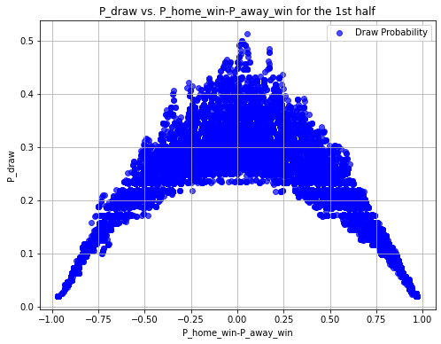

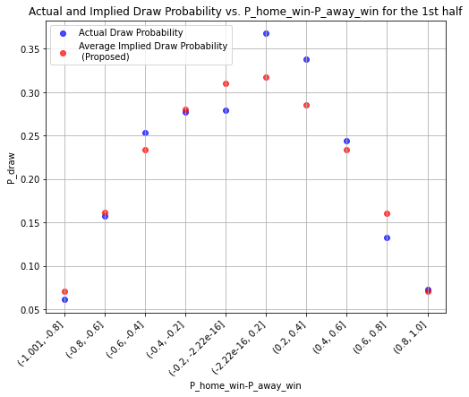

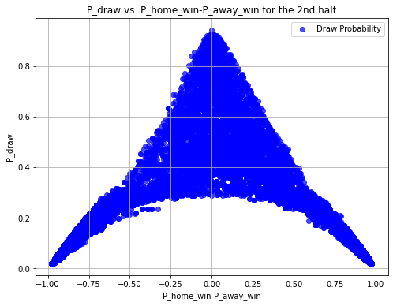

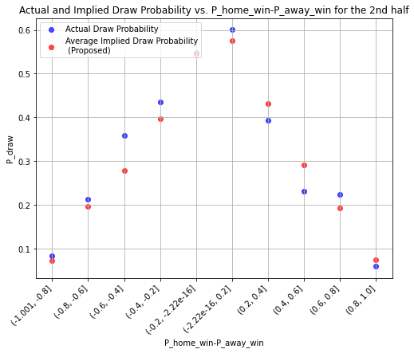

```python
for i in range(len(half_divided_match_data)):
    if i == 0:
        plot_with_probability_calculation(half_divided_match_data[i], first_half=True)
        plot_with_actual_probabilities(actual_probability_estimation_for_halves[i], first_half=True)
    else:
        plot_with_probability_calculation(half_divided_match_data[i], first_half=False)
        plot_with_actual_probabilities(actual_probability_estimation_for_halves[i], first_half=False)
```

To assess bias, the red(implied draw probabilities) and blue dots(actual draw probabilities) on the actual and implied draw probability plots are evaluated. In general, the estimated or in other words, draw probabilities calculated from the results and implied draw probabilities are close to each other. There are no specific trend/behavior of the implied probabilities(red dots). For both of the halves, the red dots don't consistently fall below or above the blue dots. Instead, the implied probabilities are positioned differently depending on the 'P_home_win-P_away_win' interval. Therefore, there is no specific trend or bias except differences in probabilities in some cases, the bookmaker's odds are well set.

In the bins/intervals where the actual draw probability is higher than the implied draw probability like [-0.6, -0.4] and [0, 0.2], one can bet on draw and earn money in the long run.

### Task 2

Case 1: Think of a match in which a team wins with a goal towards the end of the game (i.e. the team scores the winning goal after 90th minute) or similarly match ends draw (tie) or away because of the same reason.

In this case, the matches in which the current state was changed due to one or more goals scored towards the end of the game are removed from the dataset and the third and forth subtask of Task 1 are performed using the updated dataset. Specifically, the matches where the current state of the match was changed after 85th minute are removed to discard the noise from the data. The reason of this decision is to get rid of the outliers/noises in the data while preserving a large portion of the data. In order to do so, the last 5 minutes of each game, as well as the extra time, are considered to be reasonable.

```python
total_match_count = filtered_match_data['fixture_id'].nunique()
#Filter the match data after 85th minute of the game
match_data_after_85th_minute = filtered_match_data[(filtered_match_data['halftime'] == '2nd-half') & (filtered_match_data['minute'] >= 40)]
match_data_after_85th_minute = match_data_after_85th_minute.dropna(subset=['minute', 'current_state'])

state_changes = match_data_after_85th_minute.groupby('fixture_id')['current_state'].apply(lambda x: x.nunique() > 1)
changing_match_ids = state_changes[state_changes].index


filtered_match_data_case1 = filtered_match_data[~filtered_match_data['fixture_id'].isin(changing_match_ids)]
filtered_match_count_case1 = filtered_match_data_case1['fixture_id'].nunique()


print('Total Number of Matches: ' + str(total_match_count))
print('Total Number of Matches After Removing the Changing Matches: ' + str(filtered_match_count_case1))
print('Number of Matches Removed: ' + str(total_match_count-filtered_match_count_case1))

display(filtered_match_data_case1)

first_half_match_data_case1 = filtered_match_data_case1[filtered_match_data_case1['halftime'] == '1st-half']
second_half_match_data_case1 = filtered_match_data_case1[filtered_match_data_case1['halftime'] == '2nd-half']
half_divided_match_data_case1 = [first_half_match_data_case1,second_half_match_data_case1]
actual_probability_estimation_for_halves_case1 = [None, None]
```

```
Total Number of Matches: 648
Total Number of Matches After Removing the Changing Matches: 574
Number of Matches Removed: 74
```

|  | fixture_id | halftime | current_time | half_start_datetime | match_start_datetime | minute | second | latest_bookmaker_update | suspended | stopped | ... | current_state | final_score | result | P_home-win | P_draw | P_away-win | P_total | P_home-win_normalized | P_draw_normalized | P_away-win_normalized |
| --- | --- | --- | --- | --- | --- | --- | --- | --- | --- | --- | --- | --- | --- | --- | --- | --- | --- | --- | --- | --- | --- |
| 0 | 19172016.0 | 1st-half | 2024-08-09 18:11:36 | 2024-08-09 18:01:37 | 2024-08-09 18:01:37 | 9 | 59 | 2024-08-09 18:11:28 | False | False | ... | X | 2-1 | 1 | 0.819672 | 0.153846 | 0.100000 | 1.073518 | 0.763538 | 0.143310 | 0.093152 |
| 1 | 19172016.0 | 1st-half | 2024-08-09 18:27:30 | 2024-08-09 18:01:37 | 2024-08-09 18:01:37 | 25 | 53 | 2024-08-09 18:27:24 | False | False | ... | X | 2-1 | 1 | 0.833333 | 0.166667 | 0.076923 | 1.076923 | 0.773810 | 0.154762 | 0.071429 |
| 2 | 19172016.0 | 1st-half | 2024-08-09 18:28:25 | 2024-08-09 18:01:37 | 2024-08-09 18:01:37 | 26 | 48 | 2024-08-09 18:28:20 | False | False | ... | X | 2-1 | 1 | 0.833333 | 0.166667 | 0.076923 | 1.076923 | 0.773810 | 0.154762 | 0.071429 |
| 3 | 19172016.0 | 1st-half | 2024-08-09 18:29:32 | 2024-08-09 18:01:37 | 2024-08-09 18:01:37 | 27 | 55 | 2024-08-09 18:29:28 | False | False | ... | X | 2-1 | 1 | 0.833333 | 0.166667 | 0.076923 | 1.076923 | 0.773810 | 0.154762 | 0.071429 |
| 8 | 19172016.0 | 1st-half | 2024-08-09 18:34:18 | 2024-08-09 18:01:37 | 2024-08-09 18:01:37 | 32 | 41 | 2024-08-09 18:34:12 | False | False | ... | X | 2-1 | 1 | 0.833333 | 0.166667 | 0.066667 | 1.066667 | 0.781250 | 0.156250 | 0.062500 |
| ... | ... | ... | ... | ... | ... | ... | ... | ... | ... | ... | ... | ... | ... | ... | ... | ... | ... | ... | ... | ... | ... |
| 63937 | 19135376.0 | 2nd-half | 2024-11-10 21:51:41 | 2024-11-10 21:06:59 | 2024-11-10 20:02:05 | 44 | 42 | 2024-11-10 21:51:37 | False | False | ... | 1 | 1-0 | 1 | 0.925926 | 0.133333 | 0.007937 | 1.067196 | 0.867625 | 0.124938 | 0.007437 |
| 63938 | 19135376.0 | 2nd-half | 2024-11-10 21:52:41 | 2024-11-10 21:06:59 | 2024-11-10 20:02:05 | 45 | 42 | 2024-11-10 21:52:37 | False | False | ... | 1 | 1-0 | 1 | 0.952381 | 0.090909 | 0.003984 | 1.047274 | 0.909390 | 0.086805 | 0.003804 |
| 63939 | 19135376.0 | 2nd-half | 2024-11-10 21:53:41 | 2024-11-10 21:06:59 | 2024-11-10 20:02:05 | 46 | 42 | 2024-11-10 21:53:35 | False | False | ... | 1 | 1-0 | 1 | 0.952381 | 0.090909 | 0.004975 | 1.048265 | 0.908531 | 0.086723 | 0.004746 |
| 63940 | 19135376.0 | 2nd-half | 2024-11-10 21:54:41 | 2024-11-10 21:06:59 | 2024-11-10 20:02:05 | 47 | 42 | 2024-11-10 21:54:36 | False | False | ... | 1 | 1-0 | 1 | 0.961538 | 0.076923 | 0.002849 | 1.041311 | 0.923393 | 0.073871 | 0.002736 |
| 63941 | 19135376.0 | 2nd-half | 2024-11-10 21:55:41 | 2024-11-10 21:06:59 | 2024-11-10 20:02:05 | 48 | 42 | 2024-11-10 21:55:36 | False | False | ... | 1 | 1-0 | 1 | 0.980392 | 0.058824 | 0.001996 | 1.041212 | 0.941588 | 0.056495 | 0.001917 |

49349 rows × 113 columns

```python
for i in range(len(half_divided_match_data_case1)):
    half_divided_match_data_case1[i]['P_home_win-P_away_win'] = half_divided_match_data_case1[i]["P_home-win_normalized"]-half_divided_match_data_case1[i]["P_away-win_normalized"]
    if i == 0:
        actual_probability_estimation_for_halves_case1[i] = estimate_actual_probability_of_draw(half_divided_match_data_case1[i],first_half=True)
    else:
        actual_probability_estimation_for_halves_case1[i] = estimate_actual_probability_of_draw(half_divided_match_data_case1[i],first_half=False)
```

```
Actual Probability Estimation for the 1st half
```

| P_home_win-P_away_win_Bin | Draw_Games | Total_Games | Estimated_Probability_of_Draw | Average_Draw_Probability_According_to_Bookmaker |
| --- | --- | --- | --- | --- |
| (-1.001, -0.8] | 13 | 632 | 0.020570 | 0.069438 |
| (-0.8, -0.6] | 121 | 1193 | 0.101425 | 0.160637 |
| (-0.6, -0.4] | 354 | 1718 | 0.206054 | 0.234638 |
| (-0.4, -0.2] | 682 | 2641 | 0.258236 | 0.281101 |
| (-0.2, -2.22e-16] | 901 | 3512 | 0.256549 | 0.310066 |
| (-2.22e-16, 0.2] | 1828 | 4975 | 0.367437 | 0.318997 |
| (0.2, 0.4] | 1132 | 3663 | 0.309036 | 0.285809 |
| (0.4, 0.6] | 608 | 3054 | 0.199083 | 0.233452 |
| (0.6, 0.8] | 338 | 2954 | 0.114421 | 0.161021 |
| (0.8, 1.0] | 90 | 1497 | 0.060120 | 0.070409 |

```
Actual Probability Estimation for the 2nd half
```

| P_home_win-P_away_win_Bin | Draw_Games | Total_Games | Estimated_Probability_of_Draw | Average_Draw_Probability_According_to_Bookmaker |
| --- | --- | --- | --- | --- |
| (-1.001, -0.8] | 139 | 3323 | 0.041830 | 0.071347 |
| (-0.8, -0.6] | 288 | 2032 | 0.141732 | 0.195426 |
| (-0.6, -0.4] | 318 | 929 | 0.342304 | 0.273433 |
| (-0.4, -0.2] | 389 | 853 | 0.456038 | 0.397221 |
| (-0.2, -2.22e-16] | 1240 | 2083 | 0.595295 | 0.540330 |
| (-2.22e-16, 0.2] | 2380 | 3608 | 0.659645 | 0.574288 |
| (0.2, 0.4] | 713 | 1606 | 0.443960 | 0.425641 |
| (0.4, 0.6] | 240 | 1230 | 0.195122 | 0.293338 |
| (0.6, 0.8] | 241 | 2483 | 0.097060 | 0.192891 |
| (0.8, 1.0] | 170 | 5363 | 0.031699 | 0.073936 |

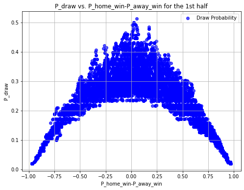

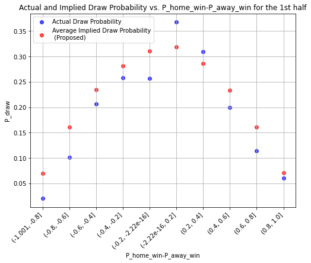

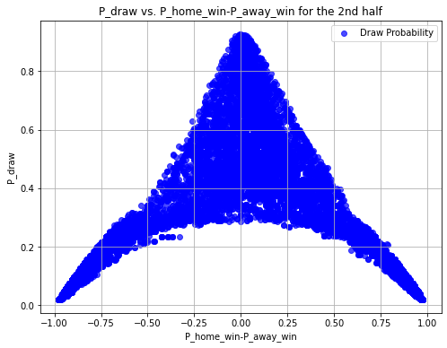

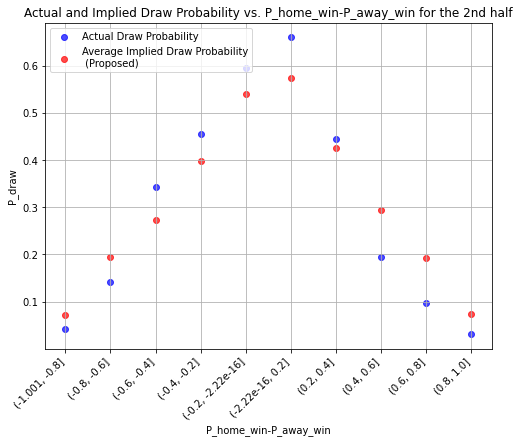

```python
for i in range(len(half_divided_match_data_case1)):
    if i == 0:
        plot_with_probability_calculation(half_divided_match_data_case1[i], first_half=True)
        plot_with_actual_probabilities(actual_probability_estimation_for_halves_case1[i], first_half=True)
    else:
        plot_with_probability_calculation(half_divided_match_data_case1[i], first_half=False)
        plot_with_actual_probabilities(actual_probability_estimation_for_halves_case1[i], first_half=False)
```

After removing the noise because of the late score changes towards the end of the game, it is observed that the bookmaker's odds tend to overestimate the probability of draws in the first half when the away team is perceived to be stronger than the home team. This behavior disappears when the noisy 74 match data is included, indicating that late game statistics can distort the trend. For the second half, the opposite situation happens. The bookmaker's implied probabilities reside below the actual probabilities meaning that one can make profits from this situation in the long run when the probability of away team win is closer to the probability of home team win. (The bins: [-0.6, -0.4], [-0.4, -0.2], [-0.2, 0], [0, 0.2]) Briefly, the bookmaker overestimates the draw probabilities in the first half in the games where away team is thought to be stronger and, the bookmaker underestimates the draw probabilities in the second half in the games where the teams are close to each other in terms of performance.

Case 2: Bookings can affect the game result. A red card in the first few minutes of a game can change the outcome of the match drastically. Playing with few players is always a disadvantage for the teams.

In this case, the matches in which a red card was issued at the beginning of the game are removed from the dataset and the third and forth subtask of Task 1 are performed using the updated dataset. Specifically, the matches where a red card was issued within the first 15 minutes are removed to discard the noise from the data. The selection of the first 15 minutes of the games comes from the fact that an early red card can drastically influence the outcome due to energy-related factors. For example, if a team receives a red card in the early stages, they would get tired more quickly because of the decrease in the number of players and in turn, it would affect the dynamics of the game which creates noises in the data. Under these circumstances, it is thought that first 15 minutes could be helpful to reduce noise in the data because of the early red cards.

```python
#Filter the match data first 15 minutes of the game
match_data_first_15_minutes = filtered_match_data[(filtered_match_data['halftime'] == '1st-half') & (filtered_match_data['minute'] <= 15)]
matches_with_red_cards = match_data_first_15_minutes[
    (match_data_first_15_minutes['Redcards - home'] > 0) |
    (match_data_first_15_minutes['Redcards - away'] > 0) |
    (match_data_first_15_minutes['Yellowred Cards - home'] > 0) |
    (match_data_first_15_minutes['Yellowred Cards - away'] > 0)
]['fixture_id'].unique()

filtered_match_data_case2 = filtered_match_data[~filtered_match_data['fixture_id'].isin(matches_with_red_cards)]
filtered_match_count_case2 = filtered_match_data_case2['fixture_id'].nunique()


print('Total Number of Matches: ' + str(total_match_count))
print('Total Number of Matches After Removing the Matches with Red Cards (First 15 minutes): ' + str(filtered_match_count_case2))
print('Number of Matches Removed: ' + str(total_match_count-filtered_match_count_case2))

display(filtered_match_data_case2[['fixture_id', 'minute', 'Redcards - home', 'Redcards - away']])


first_half_match_data_case2 = filtered_match_data_case2[filtered_match_data_case2['halftime'] == '1st-half']
second_half_match_data_case2 = filtered_match_data_case2[filtered_match_data_case2['halftime'] == '2nd-half']
half_divided_match_data_case2 = [first_half_match_data_case2,second_half_match_data_case2]
actual_probability_estimation_for_halves_case2 = [None, None]
```

```
Total Number of Matches: 648
Total Number of Matches After Removing the Matches with Red Cards (First 15 minutes): 646
Number of Matches Removed: 2
```

|  | fixture_id | minute | Redcards - home | Redcards - away |
| --- | --- | --- | --- | --- |
| 0 | 19172016.0 | 9 | 0.0 | 0.0 |
| 1 | 19172016.0 | 25 | 0.0 | 0.0 |
| 2 | 19172016.0 | 26 | 0.0 | 0.0 |
| 3 | 19172016.0 | 27 | 0.0 | 0.0 |
| 8 | 19172016.0 | 32 | 0.0 | 0.0 |
| ... | ... | ... | ... | ... |
| 63937 | 19135376.0 | 44 | 0.0 | 0.0 |
| 63938 | 19135376.0 | 45 | 0.0 | 0.0 |
| 63939 | 19135376.0 | 46 | 0.0 | 0.0 |
| 63940 | 19135376.0 | 47 | 0.0 | 0.0 |
| 63941 | 19135376.0 | 48 | 0.0 | 0.0 |

55934 rows × 4 columns

```python
for i in range(len(half_divided_match_data_case2)):
    half_divided_match_data_case2[i]['P_home_win-P_away_win'] = half_divided_match_data_case2[i]["P_home-win_normalized"]-half_divided_match_data_case2[i]["P_away-win_normalized"]
    if i == 0:
        actual_probability_estimation_for_halves_case2[i] = estimate_actual_probability_of_draw(half_divided_match_data_case2[i],first_half=True)
    else:
        actual_probability_estimation_for_halves_case2[i] = estimate_actual_probability_of_draw(half_divided_match_data_case2[i],first_half=False)
```

```
Actual Probability Estimation for the 1st half
```

| P_home_win-P_away_win_Bin | Draw_Games | Total_Games | Estimated_Probability_of_Draw | Average_Draw_Probability_According_to_Bookmaker |
| --- | --- | --- | --- | --- |
| (-1.001, -0.8] | 41 | 664 | 0.061747 | 0.070634 |
| (-0.8, -0.6] | 209 | 1322 | 0.158094 | 0.161599 |
| (-0.6, -0.4] | 472 | 1912 | 0.246862 | 0.233601 |
| (-0.4, -0.2] | 844 | 3039 | 0.277723 | 0.280511 |
| (-0.2, -2.22e-16] | 1120 | 4088 | 0.273973 | 0.310124 |
| (-2.22e-16, 0.2] | 2098 | 5713 | 0.367233 | 0.317142 |
| (0.2, 0.4] | 1405 | 4159 | 0.337822 | 0.285119 |
| (0.4, 0.6] | 852 | 3462 | 0.246101 | 0.234074 |
| (0.6, 0.8] | 412 | 3096 | 0.133075 | 0.160825 |
| (0.8, 1.0] | 116 | 1596 | 0.072682 | 0.070454 |

```
Actual Probability Estimation for the 2nd half
```

| P_home_win-P_away_win_Bin | Draw_Games | Total_Games | Estimated_Probability_of_Draw | Average_Draw_Probability_According_to_Bookmaker |
| --- | --- | --- | --- | --- |
| (-1.001, -0.8] | 297 | 3549 | 0.083686 | 0.073434 |
| (-0.8, -0.6] | 487 | 2283 | 0.213316 | 0.195984 |
| (-0.6, -0.4] | 385 | 1115 | 0.345291 | 0.276047 |
| (-0.4, -0.2] | 472 | 1104 | 0.427536 | 0.395374 |
| (-0.2, -2.22e-16] | 1409 | 2576 | 0.546972 | 0.543202 |
| (-2.22e-16, 0.2] | 2571 | 4283 | 0.600280 | 0.576242 |
| (0.2, 0.4] | 768 | 1941 | 0.395672 | 0.430645 |
| (0.4, 0.6] | 326 | 1395 | 0.233692 | 0.292229 |
| (0.6, 0.8] | 662 | 2956 | 0.223951 | 0.193143 |
| (0.8, 1.0] | 344 | 5681 | 0.060553 | 0.074930 |

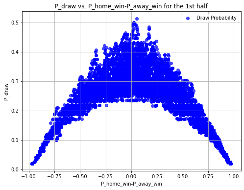

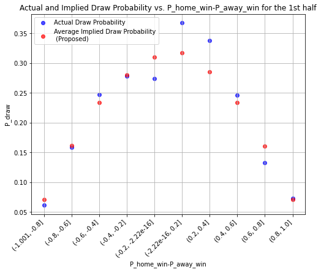

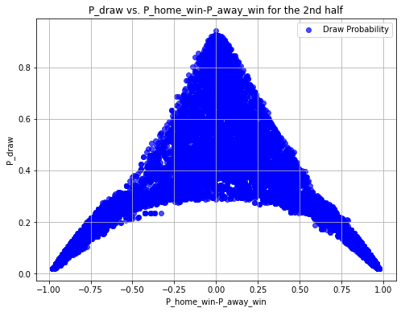

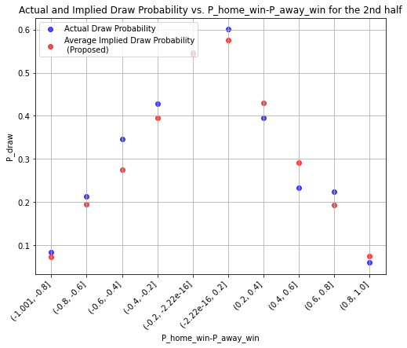

```python
for i in range(len(half_divided_match_data_case2)):
    if i == 0:
        plot_with_probability_calculation(half_divided_match_data_case2[i], first_half=True)
        plot_with_actual_probabilities(actual_probability_estimation_for_halves_case2[i], first_half=True)
    else:
        plot_with_probability_calculation(half_divided_match_data_case2[i], first_half=False)
        plot_with_actual_probabilities(actual_probability_estimation_for_halves_case2[i], first_half=False)
```

After removing the matches where the red card was issued in the first 15 minutes, it seems that there is nothing changed for the first half in terms of actual and implied probabilities. Additionally, the plot for actual and implied draw probabilities in the second half is not changed. The reason of no significant changes in these plots is that the number of removed matches are 2 and the effect of removing these matches is insignificant when the dataset of 648 matches considered. Therefore, the actual and implied probabilities remain close to each other and there is no specific trend or bias detected in this case.

### Task 3

In this task, two decision tree models are going to be fitted to predict the outcome of the games. The first model takes into account each feature including the odds determined by the bookmaker. The other model does not involve the odds and focuses solely on the game statistics.

At first, the cumulative minute of the each game is calculated using minute and halftime information to be used as feature in the decision tree models.

```python
match_data_dt = match_data.copy()
match_data_dt['cumulative_minute'] = match_data_dt.apply(
    lambda row: row['minute'] if row['halftime'] == '1st-half'
    else row['minute'] + 45, axis=1
)
display(match_data_dt)
```

|  | fixture_id | halftime | current_time | half_start_datetime | match_start_datetime | minute | second | latest_bookmaker_update | suspended | stopped | ... | Total Crosses - away | Total Crosses - home | Yellowcards - away | Yellowcards - home | Yellowred Cards - away | Yellowred Cards - home | current_state | final_score | result | cumulative_minute |
| --- | --- | --- | --- | --- | --- | --- | --- | --- | --- | --- | --- | --- | --- | --- | --- | --- | --- | --- | --- | --- | --- |
| 0 | 19172016.0 | 1st-half | 2024-08-09 18:11:36 | 2024-08-09 18:01:37 | 2024-08-09 18:01:37 | 9 | 59 | 2024-08-09 18:11:28 | False | False | ... | 0.0 | 3.0 | 0.0 | 0.0 | 0.0 | 0.0 | X | 2-1 | 1 | 9 |
| 1 | 19172016.0 | 1st-half | 2024-08-09 18:27:30 | 2024-08-09 18:01:37 | 2024-08-09 18:01:37 | 25 | 53 | 2024-08-09 18:27:24 | False | False | ... | 1.0 | 12.0 | 0.0 | 0.0 | 0.0 | 0.0 | X | 2-1 | 1 | 25 |
| 2 | 19172016.0 | 1st-half | 2024-08-09 18:28:25 | 2024-08-09 18:01:37 | 2024-08-09 18:01:37 | 26 | 48 | 2024-08-09 18:28:20 | False | False | ... | 1.0 | 13.0 | 0.0 | 0.0 | 0.0 | 0.0 | X | 2-1 | 1 | 26 |
| 3 | 19172016.0 | 1st-half | 2024-08-09 18:29:32 | 2024-08-09 18:01:37 | 2024-08-09 18:01:37 | 27 | 55 | 2024-08-09 18:29:28 | False | False | ... | 1.0 | 13.0 | 0.0 | 0.0 | 0.0 | 0.0 | X | 2-1 | 1 | 27 |
| 8 | 19172016.0 | 1st-half | 2024-08-09 18:34:18 | 2024-08-09 18:01:37 | 2024-08-09 18:01:37 | 32 | 41 | 2024-08-09 18:34:12 | False | False | ... | 1.0 | 14.0 | 0.0 | 0.0 | 0.0 | 0.0 | X | 2-1 | 1 | 32 |
| ... | ... | ... | ... | ... | ... | ... | ... | ... | ... | ... | ... | ... | ... | ... | ... | ... | ... | ... | ... | ... | ... |
| 63937 | 19135376.0 | 2nd-half | 2024-11-10 21:51:41 | 2024-11-10 21:06:59 | 2024-11-10 20:02:05 | 44 | 42 | 2024-11-10 21:51:37 | False | False | ... | 19.0 | 10.0 | 1.0 | 3.0 | 0.0 | 0.0 | 1 | 1-0 | 1 | 89 |
| 63938 | 19135376.0 | 2nd-half | 2024-11-10 21:52:41 | 2024-11-10 21:06:59 | 2024-11-10 20:02:05 | 45 | 42 | 2024-11-10 21:52:37 | False | False | ... | 19.0 | 10.0 | 1.0 | 3.0 | 0.0 | 0.0 | 1 | 1-0 | 1 | 90 |
| 63939 | 19135376.0 | 2nd-half | 2024-11-10 21:53:41 | 2024-11-10 21:06:59 | 2024-11-10 20:02:05 | 46 | 42 | 2024-11-10 21:53:35 | False | False | ... | 19.0 | 10.0 | 1.0 | 3.0 | 0.0 | 0.0 | 1 | 1-0 | 1 | 91 |
| 63940 | 19135376.0 | 2nd-half | 2024-11-10 21:54:41 | 2024-11-10 21:06:59 | 2024-11-10 20:02:05 | 47 | 42 | 2024-11-10 21:54:36 | False | False | ... | 19.0 | 10.0 | 1.0 | 3.0 | 0.0 | 0.0 | 1 | 1-0 | 1 | 92 |
| 63941 | 19135376.0 | 2nd-half | 2024-11-10 21:55:41 | 2024-11-10 21:06:59 | 2024-11-10 20:02:05 | 48 | 42 | 2024-11-10 21:55:36 | False | False | ... | 21.0 | 10.0 | 1.0 | 3.0 | 0.0 | 0.0 | 1 | 1-0 | 1 | 93 |

56127 rows × 107 columns

```python
for column in match_data_dt.columns:
    print(column)
```

```
fixture_id
halftime
current_time
half_start_datetime
match_start_datetime
minute
second
latest_bookmaker_update
suspended
stopped
1
2
X
name
ticking
Accurate Crosses - away
Accurate Crosses - home
Assists - away
Assists - home
Attacks - away
Attacks - home
Ball Possession % - away
Ball Possession % - home
Ball Safe - away
Ball Safe - home
Challenges - away
Challenges - home
Corners - away
Corners - home
Counter Attacks - away
Counter Attacks - home
Dangerous Attacks - away
Dangerous Attacks - home
Dribble Attempts - away
Dribble Attempts - home
Fouls - away
Fouls - home
Free Kicks - away
Free Kicks - home
Goal Attempts - away
```

[output cut: 52 more lines]

```
Successful Passes Percentage - home
Tackles - away
Tackles - home
Throwins - away
Throwins - home
Total Crosses - away
Total Crosses - home
Yellowcards - away
Yellowcards - home
Yellowred Cards - away
Yellowred Cards - home
current_state
final_score
result
cumulative_minute
```

From this feature list, "fixture_id", "halftime", "current_time", "half_start_datetime", "match_start_datetime", "minute", "second", "latest_bookmaker_update", "suspended", "stopped", "name", "ticking" and "final_score" are removed because it is assumed that either they have no effect on the result of the game or they have same value for each instance. Apart from this, the features which are thought to be important for the decision trees and more meaningful when the difference between the home and away team is taken are arranged accordingly. More specifically, the difference between the home team and away team for 'Ball Possession', 'Dangerous Attacks', 'Goal Attempts' and 'Goals' is taken and the calculated values are represented in the data as new features instead of those features used during the calculation. Under this setting, it is expected that the sign of the new feature value would give important information to predict the outcome of the game.

```python
columns_to_remove = ["halftime", "current_time", "half_start_datetime",
    "match_start_datetime", "minute", "second", "latest_bookmaker_update",
    "suspended", "stopped", "name", "ticking", "final_score"]
match_data_dt1 = match_data_dt.drop(columns=columns_to_remove)
match_data_dt1['Ball Possession % Diff'] = match_data_dt['Ball Possession % - home']-match_data_dt['Ball Possession % - away']
match_data_dt1['Dangerous Attacks Diff'] = match_data_dt['Dangerous Attacks - home']-match_data_dt['Dangerous Attacks - away']
match_data_dt1['Goal Attempts Diff'] = match_data_dt['Goal Attempts - home']-match_data_dt['Goal Attempts - away']
match_data_dt1['Goals Diff'] = match_data_dt['Goals - home']-match_data_dt['Goals - away']
columns_to_remove_2 = ["Ball Possession % - home","Ball Possession % - away","Dangerous Attacks - home",
    "Dangerous Attacks - away", "Goal Attempts - home",   "Goal Attempts - away",   "Goals - home", "Goals - away"]
match_data_dt1 = match_data_dt1.drop(columns=columns_to_remove_2)
display(match_data_dt1)
```

|  | fixture_id | 1 | 2 | X | Accurate Crosses - away | Accurate Crosses - home | Assists - away | Assists - home | Attacks - away | Attacks - home | ... | Yellowcards - home | Yellowred Cards - away | Yellowred Cards - home | current_state | result | cumulative_minute | Ball Possession % Diff | Dangerous Attacks Diff | Goal Attempts Diff | Goals Diff |
| --- | --- | --- | --- | --- | --- | --- | --- | --- | --- | --- | --- | --- | --- | --- | --- | --- | --- | --- | --- | --- | --- |
| 0 | 19172016.0 | 1.22 | 10.0 | 6.5 | 0.0 | 0.0 | NaN | NaN | 2.0 | 18.0 | ... | 0.0 | 0.0 | 0.0 | X | 1 | 9 | 44.0 | 9.0 | NaN | 0.0 |
| 1 | 19172016.0 | 1.20 | 13.0 | 6.0 | 0.0 | 1.0 | NaN | NaN | 12.0 | 40.0 | ... | 0.0 | 0.0 | 0.0 | X | 1 | 25 | 52.0 | 24.0 | NaN | 0.0 |
| 2 | 19172016.0 | 1.20 | 13.0 | 6.0 | 0.0 | 1.0 | NaN | NaN | 12.0 | 40.0 | ... | 0.0 | 0.0 | 0.0 | X | 1 | 26 | 58.0 | 24.0 | NaN | 0.0 |
| 3 | 19172016.0 | 1.20 | 13.0 | 6.0 | 0.0 | 1.0 | NaN | NaN | 12.0 | 42.0 | ... | 0.0 | 0.0 | 0.0 | X | 1 | 27 | 56.0 | 27.0 | NaN | 0.0 |
| 8 | 19172016.0 | 1.20 | 15.0 | 6.0 | 0.0 | 1.0 | NaN | NaN | 15.0 | 46.0 | ... | 0.0 | 0.0 | 0.0 | X | 1 | 32 | 58.0 | 31.0 | NaN | 0.0 |
| ... | ... | ... | ... | ... | ... | ... | ... | ... | ... | ... | ... | ... | ... | ... | ... | ... | ... | ... | ... | ... | ... |
| 63937 | 19135376.0 | 1.08 | 126.0 | 7.5 | 4.0 | 3.0 | 0.0 | 1.0 | 107.0 | 73.0 | ... | 3.0 | 0.0 | 0.0 | 1 | 1 | 89 | -36.0 | -12.0 | 6.0 | 1.0 |
| 63938 | 19135376.0 | 1.05 | 251.0 | 11.0 | 4.0 | 3.0 | 0.0 | 1.0 | 109.0 | 73.0 | ... | 3.0 | 0.0 | 0.0 | 1 | 1 | 90 | -36.0 | -12.0 | 6.0 | 1.0 |
| 63939 | 19135376.0 | 1.05 | 201.0 | 11.0 | 4.0 | 3.0 | 0.0 | 1.0 | 112.0 | 73.0 | ... | 3.0 | 0.0 | 0.0 | 1 | 1 | 91 | -36.0 | -15.0 | 6.0 | 1.0 |
| 63940 | 19135376.0 | 1.04 | 351.0 | 13.0 | 4.0 | 3.0 | 0.0 | 1.0 | 118.0 | 73.0 | ... | 3.0 | 0.0 | 0.0 | 1 | 1 | 92 | -36.0 | -15.0 | 6.0 | 1.0 |
| 63941 | 19135376.0 | 1.02 | 501.0 | 17.0 | 4.0 | 3.0 | 0.0 | 1.0 | 122.0 | 73.0 | ... | 3.0 | 0.0 | 0.0 | 1 | 1 | 93 | -36.0 | -16.0 | 6.0 | 1.0 |

56127 rows × 91 columns

To fill the missing values on the columns, the forward and backward filling are used. Thus, the missing values are filled with the closest valid value in both directions in the corresponding game.

```python
match_data_dt1 = (
    match_data_dt1.groupby('fixture_id')
    .apply(lambda group: group.fillna(method='ffill').fillna(method='bfill'))
    .reset_index(drop=True)  # Reset index to avoid multi-index after groupby
)
display(match_data_dt1)
remaining_missing_values = match_data_dt1.isna().sum()
print(remaining_missing_values[remaining_missing_values > 0])
```

|  | fixture_id | 1 | 2 | X | Accurate Crosses - away | Accurate Crosses - home | Assists - away | Assists - home | Attacks - away | Attacks - home | ... | Yellowcards - home | Yellowred Cards - away | Yellowred Cards - home | current_state | result | cumulative_minute | Ball Possession % Diff | Dangerous Attacks Diff | Goal Attempts Diff | Goals Diff |
| --- | --- | --- | --- | --- | --- | --- | --- | --- | --- | --- | --- | --- | --- | --- | --- | --- | --- | --- | --- | --- | --- |
| 0 | 19172016.0 | 1.22 | 10.0 | 6.5 | 0.0 | 0.0 | 1.0 | 0.0 | 2.0 | 18.0 | ... | 0.0 | 0.0 | 0.0 | X | 1 | 9 | 44.0 | 9.0 | 3.0 | 0.0 |
| 1 | 19172016.0 | 1.20 | 13.0 | 6.0 | 0.0 | 1.0 | 1.0 | 0.0 | 12.0 | 40.0 | ... | 0.0 | 0.0 | 0.0 | X | 1 | 25 | 52.0 | 24.0 | 3.0 | 0.0 |
| 2 | 19172016.0 | 1.20 | 13.0 | 6.0 | 0.0 | 1.0 | 1.0 | 0.0 | 12.0 | 40.0 | ... | 0.0 | 0.0 | 0.0 | X | 1 | 26 | 58.0 | 24.0 | 3.0 | 0.0 |
| 3 | 19172016.0 | 1.20 | 13.0 | 6.0 | 0.0 | 1.0 | 1.0 | 0.0 | 12.0 | 42.0 | ... | 0.0 | 0.0 | 0.0 | X | 1 | 27 | 56.0 | 27.0 | 3.0 | 0.0 |
| 4 | 19172016.0 | 1.20 | 15.0 | 6.0 | 0.0 | 1.0 | 1.0 | 0.0 | 15.0 | 46.0 | ... | 0.0 | 0.0 | 0.0 | X | 1 | 32 | 58.0 | 31.0 | 3.0 | 0.0 |
| ... | ... | ... | ... | ... | ... | ... | ... | ... | ... | ... | ... | ... | ... | ... | ... | ... | ... | ... | ... | ... | ... |
| 56122 | 19135376.0 | 1.08 | 126.0 | 7.5 | 4.0 | 3.0 | 0.0 | 1.0 | 107.0 | 73.0 | ... | 3.0 | 0.0 | 0.0 | 1 | 1 | 89 | -36.0 | -12.0 | 6.0 | 1.0 |
| 56123 | 19135376.0 | 1.05 | 251.0 | 11.0 | 4.0 | 3.0 | 0.0 | 1.0 | 109.0 | 73.0 | ... | 3.0 | 0.0 | 0.0 | 1 | 1 | 90 | -36.0 | -12.0 | 6.0 | 1.0 |
| 56124 | 19135376.0 | 1.05 | 201.0 | 11.0 | 4.0 | 3.0 | 0.0 | 1.0 | 112.0 | 73.0 | ... | 3.0 | 0.0 | 0.0 | 1 | 1 | 91 | -36.0 | -15.0 | 6.0 | 1.0 |
| 56125 | 19135376.0 | 1.04 | 351.0 | 13.0 | 4.0 | 3.0 | 0.0 | 1.0 | 118.0 | 73.0 | ... | 3.0 | 0.0 | 0.0 | 1 | 1 | 92 | -36.0 | -15.0 | 6.0 | 1.0 |
| 56126 | 19135376.0 | 1.02 | 501.0 | 17.0 | 4.0 | 3.0 | 0.0 | 1.0 | 122.0 | 73.0 | ... | 3.0 | 0.0 | 0.0 | 1 | 1 | 93 | -36.0 | -16.0 | 6.0 | 1.0 |

56127 rows × 91 columns

```
Assists - away                 8909
Assists - home                 8909
Ball Safe - away               7211
Ball Safe - home               7211
Counter Attacks - away        28066
Counter Attacks - home        28066
Dribble Attempts - away          30
Dribble Attempts - home          30
Fouls - away                      6
Fouls - home                      6
Free Kicks - away             51070
Free Kicks - home             51070
Goal Kicks - away               560
Goal Kicks - home               560
Headers - away                 4262
Headers - home                 4262
Injuries - away               25464
Injuries - home               25464
Key Passes - away                 6
Key Passes - home                 6
Long Passes - away             2010
Long Passes - home             2010
Offsides - away                2823
Offsides - home                2823
Saves - away                    198
Saves - home                    198
Successful Dribbles - away        6
Successful Dribbles - home        6
Successful Headers - away      4262
Successful Headers - home      4262
Yellowred Cards - away         7128
Yellowred Cards - home         7128
Goal Attempts Diff             8229
dtype: int64
```

After the forward and backward filling, the remaining features that have missing values are dropped out of the feature list except the 'Yellowred Cards' since it is thought that the effect of these features are included in other features. The decision of discarding them is made for using the all instances. To fill the missing values on the 'Yellowred Cards' column, 0's are placed.

```python
match_data_dt1['Yellowred Cards - away'] = match_data_dt1['Yellowred Cards - away'].fillna(0)
match_data_dt1['Yellowred Cards - home'] = match_data_dt1['Yellowred Cards - home'].fillna(0)
missing_columns = match_data_dt1.columns[match_data_dt1.isna().any()].tolist()
match_data_dt1 = match_data_dt1.drop(columns=['fixture_id'] + missing_columns)
match_data_dt2 = match_data_dt1.drop(columns=['1','2','X'])
```

```python
#Label encode the target and categorical variable (Result and Current State)
label_encoder = LabelEncoder()
match_data_dt1['result'] = label_encoder.fit_transform(match_data_dt1['result'])
match_data_dt2['result'] = label_encoder.fit_transform(match_data_dt2['result'])
match_data_dt1['current_state'] = label_encoder.fit_transform(match_data_dt1['current_state'])
match_data_dt2['current_state'] = label_encoder.fit_transform(match_data_dt2['current_state'])
display(match_data_dt1)

#Separate Target and Features
X1 = match_data_dt1.drop(['result'], axis=1)
y1 = match_data_dt1['result']
X2 = match_data_dt2.drop(['result'], axis=1)
y2 = match_data_dt2['result']

#Train and Test Splits
X1_train, X1_test, y1_train, y1_test = train_test_split(X1, y1, test_size=0.3, random_state=42)
X2_train, X2_test, y2_train, y2_test = train_test_split(X2, y2, test_size=0.3, random_state=42)

dt_model1 = DecisionTreeClassifier(random_state=42)

# Define the parameter grid for GridSearchCV
param_grid = {
    'max_depth': [3, 5, 7, 10, 12],
    'min_samples_split': [2, 5, 10],
    'ccp_alpha': [0.0, 0.01, 0.1, 0.5]}

# Initialize GridSearchCV with cross-validation
grid_search1 = GridSearchCV(estimator=dt_model1, param_grid=param_grid,
                            cv=StratifiedKFold(n_splits=5, shuffle=True, random_state=42),
                            scoring='accuracy', n_jobs=-1)

# Perform Grid Search for Model 1
grid_search1.fit(X1_train, y1_train)


print("Best Hyperparameters for Model 1:", grid_search1.best_params_)
print("Best Cross-Validation Accuracy for Model 1:", grid_search1.best_score_)

best_model1 = grid_search1.best_estimator_
y1_pred = best_model1.predict(X1_test)
# Performance Measures for Model 1
print("Accuracy for Model 1 on Test Set:", accuracy_score(y1_test, y1_pred))
print("Classification Report for Model 1:\n", classification_report(y1_test, y1_pred))

# Perform Grid Search for Model 2 with similar steps
dt_model2 = DecisionTreeClassifier(random_state=42)
grid_search2 = GridSearchCV(estimator=dt_model2, param_grid=param_grid,
                            cv=StratifiedKFold(n_splits=5, shuffle=True, random_state=42),
                            scoring='accuracy', n_jobs=-1)

grid_search2.fit(X2_train, y2_train)

print("Best Hyperparameters for Model 2:", grid_search2.best_params_)
print("Best Cross-Validation Accuracy for Model 2:", grid_search2.best_score_)

best_model2 = grid_search2.best_estimator_
y2_pred = best_model2.predict(X2_test)
# Performance Measures for Model 2
print("Accuracy for Model 2 on Test Set:", accuracy_score(y2_test, y2_pred))
print("Classification Report for Model 2:\n", classification_report(y2_test, y2_pred))
```

|  | 1 | 2 | X | Accurate Crosses - away | Accurate Crosses - home | Attacks - away | Attacks - home | Challenges - away | Challenges - home | Corners - away | ... | Yellowcards - away | Yellowcards - home | Yellowred Cards - away | Yellowred Cards - home | current_state | result | cumulative_minute | Ball Possession % Diff | Dangerous Attacks Diff | Goals Diff |
| --- | --- | --- | --- | --- | --- | --- | --- | --- | --- | --- | --- | --- | --- | --- | --- | --- | --- | --- | --- | --- | --- |
| 0 | 1.22 | 10.0 | 6.5 | 0.0 | 0.0 | 2.0 | 18.0 | 1.0 | 1.0 | 0.0 | ... | 0.0 | 0.0 | 0.0 | 0.0 | 2 | 0 | 9 | 44.0 | 9.0 | 0.0 |
| 1 | 1.20 | 13.0 | 6.0 | 0.0 | 1.0 | 12.0 | 40.0 | 2.0 | 2.0 | 1.0 | ... | 0.0 | 0.0 | 0.0 | 0.0 | 2 | 0 | 25 | 52.0 | 24.0 | 0.0 |
| 2 | 1.20 | 13.0 | 6.0 | 0.0 | 1.0 | 12.0 | 40.0 | 2.0 | 2.0 | 1.0 | ... | 0.0 | 0.0 | 0.0 | 0.0 | 2 | 0 | 26 | 58.0 | 24.0 | 0.0 |
| 3 | 1.20 | 13.0 | 6.0 | 0.0 | 1.0 | 12.0 | 42.0 | 2.0 | 2.0 | 1.0 | ... | 0.0 | 0.0 | 0.0 | 0.0 | 2 | 0 | 27 | 56.0 | 27.0 | 0.0 |
| 4 | 1.20 | 15.0 | 6.0 | 0.0 | 1.0 | 15.0 | 46.0 | 2.0 | 3.0 | 1.0 | ... | 0.0 | 0.0 | 0.0 | 0.0 | 2 | 0 | 32 | 58.0 | 31.0 | 0.0 |
| ... | ... | ... | ... | ... | ... | ... | ... | ... | ... | ... | ... | ... | ... | ... | ... | ... | ... | ... | ... | ... | ... |
| 56122 | 1.08 | 126.0 | 7.5 | 4.0 | 3.0 | 107.0 | 73.0 | 3.0 | 11.0 | 6.0 | ... | 1.0 | 3.0 | 0.0 | 0.0 | 0 | 0 | 89 | -36.0 | -12.0 | 1.0 |
| 56123 | 1.05 | 251.0 | 11.0 | 4.0 | 3.0 | 109.0 | 73.0 | 3.0 | 11.0 | 6.0 | ... | 1.0 | 3.0 | 0.0 | 0.0 | 0 | 0 | 90 | -36.0 | -12.0 | 1.0 |
| 56124 | 1.05 | 201.0 | 11.0 | 4.0 | 3.0 | 112.0 | 73.0 | 3.0 | 11.0 | 6.0 | ... | 1.0 | 3.0 | 0.0 | 0.0 | 0 | 0 | 91 | -36.0 | -15.0 | 1.0 |
| 56125 | 1.04 | 351.0 | 13.0 | 4.0 | 3.0 | 118.0 | 73.0 | 3.0 | 11.0 | 6.0 | ... | 1.0 | 3.0 | 0.0 | 0.0 | 0 | 0 | 92 | -36.0 | -15.0 | 1.0 |
| 56126 | 1.02 | 501.0 | 17.0 | 4.0 | 3.0 | 122.0 | 73.0 | 4.0 | 13.0 | 6.0 | ... | 1.0 | 3.0 | 0.0 | 0.0 | 0 | 0 | 93 | -36.0 | -16.0 | 1.0 |

56127 rows × 59 columns

```
Best Hyperparameters for Model 1: {'ccp_alpha': 0.0, 'max_depth': 12, 'min_samples_split': 2}
Best Cross-Validation Accuracy for Model 1: 0.8076256019851927
Accuracy for Model 1 on Test Set: 0.812756101906289
Classification Report for Model 1:
               precision    recall  f1-score   support

           0       0.81      0.88      0.85      7271
           1       0.86      0.77      0.81      4974
           2       0.76      0.74      0.75      4594

    accuracy                           0.81     16839
   macro avg       0.81      0.80      0.81     16839
weighted avg       0.81      0.81      0.81     16839

Best Hyperparameters for Model 2: {'ccp_alpha': 0.0, 'max_depth': 12, 'min_samples_split': 2}
Best Cross-Validation Accuracy for Model 2: 0.7826308959336872
Accuracy for Model 2 on Test Set: 0.7735613753785854
Classification Report for Model 2:
               precision    recall  f1-score   support

           0       0.75      0.88      0.81      7271
           1       0.81      0.72      0.76      4974
           2       0.78      0.66      0.72      4594

    accuracy                           0.77     16839
   macro avg       0.78      0.75      0.76     16839
weighted avg       0.78      0.77      0.77     16839
```

After performing parameter tuning by grid search and obtaining the performance results of the models, it can be said that the proposed decision tree models have similar accuracies which are approximately 80%. This indicates that even though the decision tree model 2 does not include the odds determined by the bookmaker, it has quite good performance compared to the decision tree model 1. When the other measures are observed, they have also close results. At this point, it is hard to conclude that one model outperforms the other. Before drawing conclusions, the importance of features in the models are presented below.

```
Feature Importance for Model 1:
```

|  | Feature | Importance |
| --- | --- | --- |
| 0 | 1 | 0.280023 |
| 1 | 2 | 0.132276 |
| 2 | X | 0.067573 |
| 42 | Successful Passes Percentage - home | 0.024842 |
| 55 | Ball Possession % Diff | 0.024513 |
| 39 | Successful Passes - away | 0.022088 |
| 41 | Successful Passes Percentage - away | 0.021877 |
| 4 | Accurate Crosses - home | 0.021628 |
| 45 | Throwins - away | 0.020075 |
| 10 | Corners - home | 0.019805 |
| 3 | Accurate Crosses - away | 0.016755 |
| 9 | Corners - away | 0.015710 |
| 37 | Successful Interceptions - away | 0.015341 |
| 31 | Shots Outsidebox - away | 0.015293 |
| 56 | Dangerous Attacks Diff | 0.014817 |
| 13 | Interceptions - away | 0.013739 |
| 47 | Total Crosses - away | 0.013650 |
| 33 | Shots Total - away | 0.013409 |
| 46 | Throwins - home | 0.012024 |
| 14 | Interceptions - home | 0.011747 |
| 24 | Shots Blocked - home | 0.011713 |
| 8 | Challenges - home | 0.011289 |
| 30 | Shots On Target - home | 0.010925 |
| 40 | Successful Passes - home | 0.009528 |
| 32 | Shots Outsidebox - home | 0.009345 |
| 26 | Shots Insidebox - home | 0.009296 |
| 7 | Challenges - away | 0.009162 |
| 48 | Total Crosses - home | 0.009155 |
| 28 | Shots Off Target - home | 0.009147 |
| 50 | Yellowcards - home | 0.008616 |
| 34 | Shots Total - home | 0.008459 |
| 17 | Penalties - away | 0.008433 |
| 38 | Successful Interceptions - home | 0.008151 |
| 12 | Hit Woodwork - home | 0.007258 |
| 27 | Shots Off Target - away | 0.007090 |
| 44 | Tackles - home | 0.006930 |
| 43 | Tackles - away | 0.006804 |
| 23 | Shots Blocked - away | 0.006719 |
| 25 | Shots Insidebox - away | 0.006570 |
| 29 | Shots On Target - away | 0.005881 |
| 5 | Attacks - away | 0.005871 |
| 11 | Hit Woodwork - away | 0.005822 |
| 49 | Yellowcards - away | 0.005751 |
| 16 | Passes - home | 0.005366 |
| 6 | Attacks - home | 0.004840 |
| 15 | Passes - away | 0.004466 |
| 18 | Penalties - home | 0.004333 |
| 36 | Substitutions - home | 0.003437 |
| 19 | Redcards - away | 0.002774 |
| 53 | current_state | 0.002423 |
| 57 | Goals Diff | 0.001754 |
| 52 | Yellowred Cards - home | 0.001592 |
| 20 | Redcards - home | 0.001463 |
| 54 | cumulative_minute | 0.001291 |
| 35 | Substitutions - away | 0.000447 |
| 51 | Yellowred Cards - away | 0.000426 |
| 22 | Score Change - home | 0.000290 |
| 21 | Score Change - away | 0.000000 |

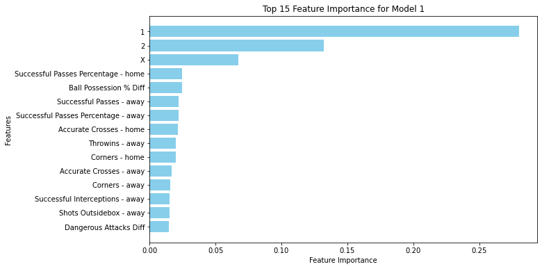

```python
feature_importance_1 = best_model1.feature_importances_
feature_importance_df1 = pd.DataFrame({
    'Feature': X1.columns,
    'Importance': feature_importance_1})

feature_importance_df1 = feature_importance_df1.sort_values(by='Importance', ascending=False)
print("Feature Importance for Model 1:")
display(feature_importance_df1)
top_15_features1 = feature_importance_df1.nlargest(15, 'Importance')

plt.figure(figsize=(10, 6))
plt.barh(top_15_features1['Feature'], top_15_features1['Importance'], color='skyblue')
plt.xlabel('Feature Importance')
plt.ylabel('Features')
plt.title('Top 15 Feature Importance for Model 1')
plt.gca().invert_yaxis()
plt.show()
```

```
Feature Importance for Model 2:
```

|  | Feature | Importance |
| --- | --- | --- |
| 50 | current_state | 0.215984 |
| 54 | Goals Diff | 0.139742 |
| 39 | Successful Passes Percentage - home | 0.034569 |
| 51 | cumulative_minute | 0.034553 |
| 52 | Ball Possession % Diff | 0.031715 |
| 44 | Total Crosses - away | 0.023962 |
| 42 | Throwins - away | 0.023472 |
| 29 | Shots Outsidebox - home | 0.022900 |
| 0 | Accurate Crosses - away | 0.021861 |
| 26 | Shots On Target - away | 0.020840 |
| 6 | Corners - away | 0.019983 |
| 24 | Shots Off Target - away | 0.019760 |
| 38 | Successful Passes Percentage - away | 0.019420 |
| 11 | Interceptions - home | 0.018811 |
| 45 | Total Crosses - home | 0.016821 |
| 53 | Dangerous Attacks Diff | 0.016639 |
| 28 | Shots Outsidebox - away | 0.016339 |
| 43 | Throwins - home | 0.015712 |
| 23 | Shots Insidebox - home | 0.015259 |
| 21 | Shots Blocked - home | 0.014130 |
| 1 | Accurate Crosses - home | 0.013532 |
| 7 | Corners - home | 0.013239 |
| 35 | Successful Interceptions - home | 0.012581 |
| 41 | Tackles - home | 0.012510 |
| 40 | Tackles - away | 0.012494 |
| 20 | Shots Blocked - away | 0.011821 |
| 30 | Shots Total - away | 0.011244 |
| 4 | Challenges - away | 0.010835 |
| 46 | Yellowcards - away | 0.010826 |
| 36 | Successful Passes - away | 0.010760 |
| 27 | Shots On Target - home | 0.009377 |
| 10 | Interceptions - away | 0.009133 |
| 9 | Hit Woodwork - home | 0.008766 |
| 5 | Challenges - home | 0.008595 |
| 25 | Shots Off Target - home | 0.008370 |
| 31 | Shots Total - home | 0.008026 |
| 3 | Attacks - home | 0.007372 |
| 2 | Attacks - away | 0.007357 |
| 13 | Passes - home | 0.007248 |
| 22 | Shots Insidebox - away | 0.007231 |
| 37 | Successful Passes - home | 0.006705 |
| 8 | Hit Woodwork - away | 0.006309 |
| 12 | Passes - away | 0.006231 |
| 14 | Penalties - away | 0.005909 |
| 34 | Successful Interceptions - away | 0.005757 |
| 15 | Penalties - home | 0.005347 |
| 32 | Substitutions - away | 0.005124 |
| 47 | Yellowcards - home | 0.004812 |
| 16 | Redcards - away | 0.004341 |
| 33 | Substitutions - home | 0.003690 |
| 48 | Yellowred Cards - away | 0.001002 |
| 17 | Redcards - home | 0.000731 |
| 19 | Score Change - home | 0.000254 |
| 49 | Yellowred Cards - home | 0.000000 |
| 18 | Score Change - away | 0.000000 |

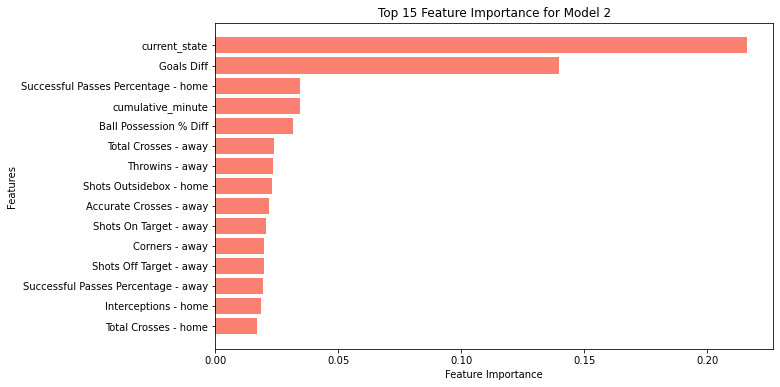

```python
feature_importance_2 = best_model2.feature_importances_
feature_importance_df2 = pd.DataFrame({
    'Feature': X2.columns,
    'Importance': feature_importance_2})
feature_importance_df2 = feature_importance_df2.sort_values(by='Importance', ascending=False)

print("\nFeature Importance for Model 2:")
display(feature_importance_df2)
top_15_features2 = feature_importance_df2.nlargest(15, 'Importance')

plt.figure(figsize=(10, 6))
plt.barh(top_15_features2['Feature'], top_15_features2['Importance'], color='salmon')
plt.xlabel('Feature Importance')
plt.ylabel('Features')
plt.title('Top 15 Feature Importance for Model 2')
plt.gca().invert_yaxis()
plt.show()
```

In the absence of odds, the second model gives importance to the current state of the game and the goal difference. It makes sense when the combined effect of those factors is considered. For instance, if the current state is 1 and the goal difference is large(i.e. 2 or more), then, the result of the game would be probably 1 generally. However, the sole effect of current state can not be ignored. Based on the feature importance values, it has the highest importance of 0.21 among the features indicating that it offers valuable information to predict the outcome of the match when the odds are not available. In other words, the current state has similar effect with the odds but has less capability to predict the outcome solely considering the importance values of other features such as 'Goals Diff','Successful Passes Percentage - home','cumulative minute', and 'Ball Possession % Diff'. From this result, it can be said that the decision tree model 2 gives more weight to the other features/game statistics to predict outcome of the match while the decision tree model 1 relies on the given odds by the bookmaker. However, there is a slight difference between them in terms of accuracy about 4% which shows that the bookmakers offer useful odds which reflect the probability of outcome of the games using the game statistics and enhance the accuracy of the decision tree model slightly. One other interesting result is that in both models, the 'Successful Passes Percentage - home' and 'Ball Possession % Diff' have remarkable importance, showing that these factors have influence on the result of the match and thus, they can be used to predict the result. To put it another way, they provide information about potential result of the match. Additionally, these importance results imply that the 'cumulative minute', 'Goals Diff' and 'current_state' information are largely incorporated into the odds by bookmaker.

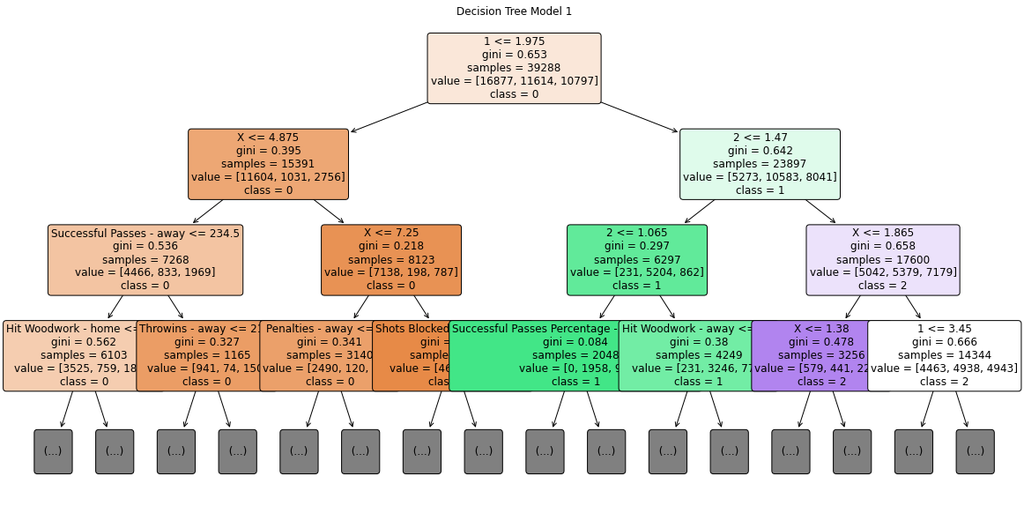

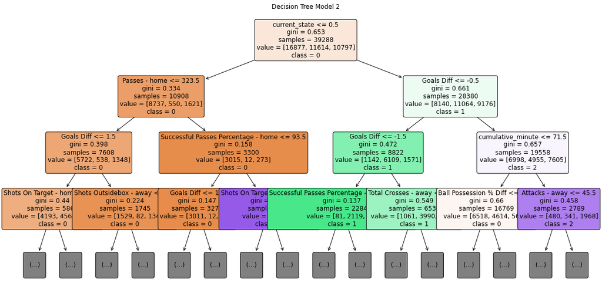

```python
# Plot the first decision tree model
class_names_1 = [str(cls) for cls in best_model1.classes_]
class_names_2 = [str(cls) for cls in best_model2.classes_]

plt.figure(figsize=(20, 10))
plot_tree(best_model1, feature_names=X1.columns, class_names=class_names_1, filled=True, rounded=True, max_depth=3, fontsize=12)
plt.title("Decision Tree Model 1")
plt.show()

# Plot the second decision tree model
plt.figure(figsize=(20, 10))
plot_tree(best_model2, feature_names=X2.columns, class_names=class_names_2, filled=True, rounded=True, max_depth=3, fontsize=12)
plt.title("Decision Tree Model 2")
plt.show()
```

```
Mean Deviation for Home Win - Model 1: 0.0057531727292712866
Mean Deviation for Draw - Model 1: 0.03274699511232485
Mean Deviation for Away Win - Model 1: -0.03850016784159646
Mean Deviation for Home Win - Model 2: 0.006492674743044358
Mean Deviation for Draw - Model 2: 0.028755859477396613
Mean Deviation for Away Win - Model 2: -0.035248534220441094
```

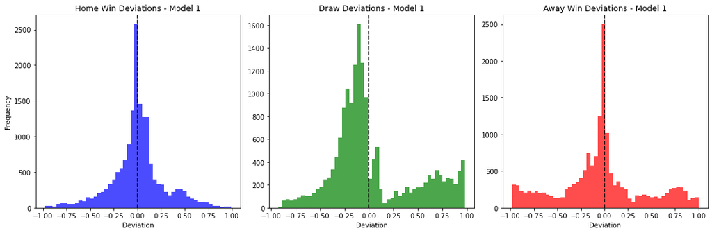

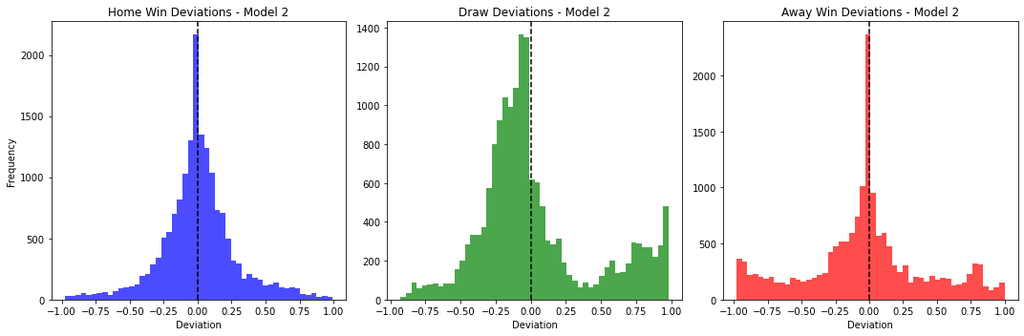

```python
#Predicted Probabilities from the Decision Tree Models and Implied Probabilities
def calculate_deviations(model, X_test, y_test, filtered_match_data, model_label):
    predicted_probs = model.predict_proba(X_test)

    implied_probs = filtered_match_data.iloc[X_test.index.values,
                                             [filtered_match_data.columns.get_loc('P_home-win_normalized'),
                                              filtered_match_data.columns.get_loc('P_draw_normalized'),
                                              filtered_match_data.columns.get_loc('P_away-win_normalized')]].values

    deviation_data = X_test.copy()
    deviation_data['True Result'] = y_test
    deviation_data[f'Predicted Home Win Probability - {model_label}'] = predicted_probs[:, 0]
    deviation_data[f'Predicted Draw Probability - {model_label}'] = predicted_probs[:, 1]
    deviation_data[f'Predicted Away Win Probability - {model_label}'] = predicted_probs[:, 2]
    deviation_data[f'Implied Home Win Probability'] = implied_probs[:, 0]
    deviation_data[f'Implied Draw Probability'] = implied_probs[:, 1]
    deviation_data[f'Implied Away Win Probability'] = implied_probs[:, 2]

    deviation_data[f'Home Win Deviation - {model_label}'] = deviation_data[f'Predicted Home Win Probability - {model_label}'] - deviation_data['Implied Home Win Probability']
    deviation_data[f'Draw Deviation - {model_label}'] = deviation_data[f'Predicted Draw Probability - {model_label}'] - deviation_data['Implied Draw Probability']
    deviation_data[f'Away Win Deviation - {model_label}'] = deviation_data[f'Predicted Away Win Probability - {model_label}'] - deviation_data['Implied Away Win Probability']

    mean_deviation_home_win = deviation_data[f'Home Win Deviation - {model_label}'].mean()
    mean_deviation_draw = deviation_data[f'Draw Deviation - {model_label}'].mean()
    mean_deviation_away_win = deviation_data[f'Away Win Deviation - {model_label}'].mean()

    print(f"Mean Deviation for Home Win - {model_label}: {mean_deviation_home_win}")
    print(f"Mean Deviation for Draw - {model_label}: {mean_deviation_draw}")
    print(f"Mean Deviation for Away Win - {model_label}: {mean_deviation_away_win}")

    return deviation_data

# Calculate deviations for both models
deviation_data1 = calculate_deviations(best_model1, X1_test, y1_test, filtered_match_data, 'Model 1')
deviation_data2 = calculate_deviations(best_model2, X2_test, y2_test, filtered_match_data, 'Model 2')

# Plot deviations for Model 1
plt.figure(figsize=(15, 5))

plt.subplot(1, 3, 1)
plt.hist(deviation_data1['Home Win Deviation - Model 1'], bins=50, color='blue', alpha=0.7)
plt.axvline(0, color='black', linestyle='--')
plt.title("Home Win Deviations - Model 1")
plt.xlabel("Deviation")
plt.ylabel("Frequency")

plt.subplot(1, 3, 2)
plt.hist(deviation_data1['Draw Deviation - Model 1'], bins=50, color='green', alpha=0.7)
plt.axvline(0, color='black', linestyle='--')
plt.title("Draw Deviations - Model 1")
plt.xlabel("Deviation")

plt.subplot(1, 3, 3)
plt.hist(deviation_data1['Away Win Deviation - Model 1'], bins=50, color='red', alpha=0.7)
plt.axvline(0, color='black', linestyle='--')
plt.title("Away Win Deviations - Model 1")
plt.xlabel("Deviation")

plt.tight_layout()
plt.show()

# Plot deviations for Model 2
plt.figure(figsize=(15, 5))


plt.subplot(1, 3, 1)
plt.hist(deviation_data2['Home Win Deviation - Model 2'], bins=50, color='blue', alpha=0.7)
plt.axvline(0, color='black', linestyle='--')
plt.title("Home Win Deviations - Model 2")
plt.xlabel("Deviation")
plt.ylabel("Frequency")


plt.subplot(1, 3, 2)
plt.hist(deviation_data2['Draw Deviation - Model 2'], bins=50, color='green', alpha=0.7)
plt.axvline(0, color='black', linestyle='--')
plt.title("Draw Deviations - Model 2")
plt.xlabel("Deviation")


plt.subplot(1, 3, 3)
plt.hist(deviation_data2['Away Win Deviation - Model 2'], bins=50, color='red', alpha=0.7)
plt.axvline(0, color='black', linestyle='--')
plt.title("Away Win Deviations - Model 2")
plt.xlabel("Deviation")

plt.tight_layout()
plt.show()
```

Based on the deviation plots and mean deviations, it can deduced that model 1 and model 2 behaves very similarly in terms of deviation from the implied probabilities. The model 2 which excludes the odds from the bookmaker has slightly lower deviation on average for away win and draw than the model 1 whereas, the model 1 has lower deviation for the home win on average than the model 2. However, the differences are too small and these models can be interpreted as same in terms of deviation performance. The plot below the mean deviations also supports this idea visually. As it can be observed from the plots, both models align with the implied probabilities given by the bookmaker in large extent for especially home win and away win cases. Their means are located somewhere near to zero deviation which support the claim in the previous sentence. Moreover, it can be said that the models predict draw with slightly higher probabilities than the implied probabilities but it is not that large. In fact, the mean deviation for draw and also for others do not reflect any significant bias. The decision tree models aligns best for home win with the implied probabilities. Consequently, there seems to be no remarkable inefficiency in the market (odds) when the outcomes of the decision tree models and the implied probabilities from bookmaker are compared.

## References

For this study, I referenced the article “Statistical Football Modeling A Study of Football Betting and Implementation of Statistical Algorithms in Premier League” by Jonas Mirza and Niklas Fejes (2016) to identify patterns, uncover relationships and draw conclusions in Task 1 and Task 2.